[figure not shown]

# Sommaire

```python
import pandas as pd
import numpy as np
import warnings as warnings
import matplotlib.pyplot as plt
%matplotlib inline
import scipy.stats as stats
import seaborn as sns
warnings.filterwarnings('ignore')
pd.set_option('display.max_columns', 50)
pd.set_option('display.max_rows', 500)
```

# Exploration des donnees

```python
customers = pd.read_csv("~\Documents\OpenClassrooms\Projet 6\donnees\customers.csv")
products = pd.read_csv("~\Documents\OpenClassrooms\Projet 6\donnees\products.csv")
transactions = pd.read_csv(r"~\Documents\OpenClassrooms\Projet 6\donnees\transactions.csv")
```

## Explorations et Nettoyage <h/2>

### Customers

```python
customers
```

|  | client_id | sex | birth |
| --- | --- | --- | --- |
| 0 | c_4410 | f | 1967 |
| 1 | c_7839 | f | 1975 |
| 2 | c_1699 | f | 1984 |
| 3 | c_5961 | f | 1962 |
| 4 | c_5320 | m | 1943 |
| ... | ... | ... | ... |
| 8618 | c_7920 | m | 1956 |
| 8619 | c_7403 | f | 1970 |
| 8620 | c_5119 | m | 1974 |
| 8621 | c_5643 | f | 1968 |
| 8622 | c_84 | f | 1982 |

8623 rows × 3 columns

```python
customers.info()
```

```
<class 'pandas.core.frame.DataFrame'>
RangeIndex: 8623 entries, 0 to 8622
Data columns (total 3 columns):
 #   Column     Non-Null Count  Dtype
---  ------     --------------  -----
 0   client_id  8623 non-null   object
 1   sex        8623 non-null   object
 2   birth      8623 non-null   int64
dtypes: int64(1), object(2)
memory usage: 202.2+ KB
```

```python
customers.describe(include = "all")
```

|  | client_id | sex | birth |
| --- | --- | --- | --- |
| count | 8623 | 8623 | 8623.000000 |
| unique | 8623 | 2 | NaN |
| top | c_4410 | f | NaN |
| freq | 1 | 4491 | NaN |
| mean | NaN | NaN | 1978.280877 |
| std | NaN | NaN | 16.919535 |
| min | NaN | NaN | 1929.000000 |
| 25% | NaN | NaN | 1966.000000 |
| 50% | NaN | NaN | 1979.000000 |
| 75% | NaN | NaN | 1992.000000 |
| max | NaN | NaN | 2004.000000 |

```python
customers.isna().sum()
```

```
client_id    0
sex          0
birth        0
dtype: int64
```

```python
for c in customers.columns:
    print ('\nTaux de valeur unique pour %s'% c)
    print (len(customers[c].unique()))
```

```
Taux de valeur unique pour client_id
8623

Taux de valeur unique pour sex
2

Taux de valeur unique pour birth
76
```

```python
customers['client_id'].map(str).apply(len).unique()
```

```
array([6, 5, 4, 3], dtype=int64)
```

```python
customers['client_id'].map(str).apply(len).value_counts()
```

```
6    7622
5     900
4      92
3       9
Name: client_id, dtype: int64
```

```python
AB = customers[customers['client_id'].map(str).apply(len) !=6]
AB.describe()
```

|  | birth |
| --- | --- |
| count | 1001.000000 |
| mean | 1977.769231 |
| std | 17.351763 |
| min | 1929.000000 |
| 25% | 1965.000000 |
| 50% | 1979.000000 |
| 75% | 1992.000000 |
| max | 2004.000000 |

```python
customers[customers['client_id'].map(str).apply(len) ==4]
```

|  | client_id | sex | birth |
| --- | --- | --- | --- |
| 391 | c_58 | f | 2003 |
| 593 | c_89 | m | 1971 |
| 689 | c_55 | f | 1993 |
| 818 | c_72 | m | 1968 |
| 885 | c_73 | m | 1987 |
| 904 | c_14 | f | 1971 |
| 1060 | c_53 | f | 1965 |
| 1084 | c_50 | f | 1994 |
| 1193 | c_24 | f | 1972 |
| 1245 | c_99 | m | 1963 |
| 1280 | c_70 | m | 1961 |
| 1305 | c_88 | f | 1957 |
| 1333 | c_95 | f | 1998 |
| 1396 | c_67 | f | 1965 |
| 1420 | c_59 | m | 1976 |
| 1489 | c_77 | m | 1992 |
| 1557 | c_44 | f | 1992 |
| 1746 | c_33 | m | 1982 |
| 1805 | c_23 | m | 1997 |
| 1864 | c_46 | f | 1998 |
| 1876 | c_16 | f | 1970 |
| 1913 | c_98 | m | 1986 |
| 2345 | c_83 | f | 1998 |
| 2384 | c_26 | m | 1997 |
| 2576 | c_64 | f | 1988 |
| 2587 | c_60 | f | 1984 |
| 2666 | c_75 | f | 1984 |
| 2735 | ct_0 | f | 2001 |
| 2862 | c_15 | f | 1988 |
| 2949 | c_86 | f | 1994 |

[output cut: 62 more lines]

```python
customers[customers['client_id'].map(str).apply(len) ==3]
```

|  | client_id | sex | birth |
| --- | --- | --- | --- |
| 976 | c_7 | f | 1967 |
| 2119 | c_9 | m | 1986 |
| 3554 | c_8 | m | 1975 |
| 4299 | c_1 | m | 1955 |
| 5007 | c_4 | m | 1964 |
| 5516 | c_6 | f | 2004 |
| 7110 | c_3 | m | 1979 |
| 7301 | c_2 | m | 1976 |
| 7503 | c_5 | f | 1994 |

```python
# Avec la colonne "birth" on peut calculer l'age du client
customers['age'] = 2022 - customers['birth']
```

```python
customers
```

|  | client_id | sex | birth | age |
| --- | --- | --- | --- | --- |
| 0 | c_4410 | f | 1967 | 55 |
| 1 | c_7839 | f | 1975 | 47 |
| 2 | c_1699 | f | 1984 | 38 |
| 3 | c_5961 | f | 1962 | 60 |
| 4 | c_5320 | m | 1943 | 79 |
| ... | ... | ... | ... | ... |
| 8618 | c_7920 | m | 1956 | 66 |
| 8619 | c_7403 | f | 1970 | 52 |
| 8620 | c_5119 | m | 1974 | 48 |
| 8621 | c_5643 | f | 1968 | 54 |
| 8622 | c_84 | f | 1982 | 40 |

8623 rows × 4 columns

ID de code client non uniforme, majoritairement composer de 6 caracters mais presence de 3, 4 et 5 caracteres. Faute de saisie peut etre?

### Products

```python
products
```

|  | id_prod | price | categ |
| --- | --- | --- | --- |
| 0 | 0_1421 | 19.99 | 0 |
| 1 | 0_1368 | 5.13 | 0 |
| 2 | 0_731 | 17.99 | 0 |
| 3 | 1_587 | 4.99 | 1 |
| 4 | 0_1507 | 3.99 | 0 |
| ... | ... | ... | ... |
| 3282 | 2_23 | 115.99 | 2 |
| 3283 | 0_146 | 17.14 | 0 |
| 3284 | 0_802 | 11.22 | 0 |
| 3285 | 1_140 | 38.56 | 1 |
| 3286 | 0_1920 | 25.16 | 0 |

3287 rows × 3 columns

```python
print(products.info())
print(products.describe())
```

```
<class 'pandas.core.frame.DataFrame'>
RangeIndex: 3287 entries, 0 to 3286
Data columns (total 3 columns):
 #   Column   Non-Null Count  Dtype
---  ------   --------------  -----
 0   id_prod  3287 non-null   object
 1   price    3287 non-null   float64
 2   categ    3287 non-null   int64
dtypes: float64(1), int64(1), object(1)
memory usage: 77.2+ KB
None
             price        categ
count  3287.000000  3287.000000
mean     21.856641     0.370246
std      29.847908     0.615387
min      -1.000000     0.000000
25%       6.990000     0.000000
50%      13.060000     0.000000
75%      22.990000     1.000000
max     300.000000     2.000000
```

Presence de valeurs negatifs dans le prix

```python
products.isna().sum()
```

```
id_prod    0
price      0
categ      0
dtype: int64
```

```python
for c in products.columns:
    print ('\nTaux de valeur unique pour %s'% c)
    print (len(products[c].unique()))
```

```
Taux de valeur unique pour id_prod
3287

Taux de valeur unique pour price
1455

Taux de valeur unique pour categ
3
```

```python
products["categ"].value_counts()
```

```
0    2309
1     739
2     239
Name: categ, dtype: int64
```

```python
display(products.sort_values('price', axis=0, ascending=False).head())
display(products.sort_values('price', axis=0, ascending=True).head())
```

|  | id_prod | price | categ |
| --- | --- | --- | --- |
| 947 | 2_2 | 300.00 | 2 |
| 724 | 2_76 | 254.44 | 2 |
| 394 | 2_158 | 247.22 | 2 |
| 1436 | 2_167 | 236.99 | 2 |
| 2779 | 2_30 | 233.54 | 2 |

|  | id_prod | price | categ |
| --- | --- | --- | --- |
| 731 | T_0 | -1.00 | 0 |
| 2355 | 0_202 | 0.62 | 0 |
| 2272 | 0_528 | 0.62 | 0 |
| 370 | 0_120 | 0.66 | 0 |
| 1211 | 0_1844 | 0.77 | 0 |

```python
products['id_prod'].map(str).apply(len).value_counts()
```

```
5    1678
6    1308
4     270
3      31
Name: id_prod, dtype: int64
```

```python
products[products['price'] <= 0]
```

|  | id_prod | price | categ |
| --- | --- | --- | --- |
| 731 | T_0 | -1.0 | 0 |

Je peux soupconner que la valeur T_0 est peut etre une valeur test que je verifierais plus tard si elle correspond a des id de client important a notre table de doneer.

### Transactions

```python
transactions
```

|  | id_prod | date | session_id | client_id |
| --- | --- | --- | --- | --- |
| 0 | 0_1518 | 2022-05-20 13:21:29.043970 | s_211425 | c_103 |
| 1 | 1_251 | 2022-02-02 07:55:19.149409 | s_158752 | c_8534 |
| 2 | 0_1277 | 2022-06-18 15:44:33.155329 | s_225667 | c_6714 |
| 3 | 2_209 | 2021-06-24 04:19:29.835891 | s_52962 | c_6941 |
| 4 | 0_1509 | 2023-01-11 08:22:08.194479 | s_325227 | c_4232 |
| ... | ... | ... | ... | ... |
| 679527 | 0_1551 | 2022-01-15 13:05:06.246925 | s_150195 | c_8489 |
| 679528 | 1_639 | 2022-03-19 16:03:23.429229 | s_181434 | c_4370 |
| 679529 | 0_1425 | 2022-12-20 04:33:37.584749 | s_314704 | c_304 |
| 679530 | 0_1994 | 2021-07-16 20:36:35.350579 | s_63204 | c_2227 |
| 679531 | 1_523 | 2022-09-28 01:12:01.973763 | s_274568 | c_3873 |

679532 rows × 4 columns

```python
print(transactions.info())
print(transactions.describe())
```

```
<class 'pandas.core.frame.DataFrame'>
RangeIndex: 679532 entries, 0 to 679531
Data columns (total 4 columns):
 #   Column      Non-Null Count   Dtype
---  ------      --------------   -----
 0   id_prod     679532 non-null  object
 1   date        679532 non-null  object
 2   session_id  679532 non-null  object
 3   client_id   679532 non-null  object
dtypes: object(4)
memory usage: 20.7+ MB
None
       id_prod                             date session_id client_id
count   679532                           679532     679532    679532
unique    3267                           679371     342316      8602
top      1_369  test_2021-03-01 02:30:02.237413        s_0    c_1609
freq      2252                               13        200     25488
```

```python
transactions['date'].map(str).apply(len).value_counts()
```

```
26    679332
31       200
Name: date, dtype: int64
```

```python
transactions[transactions['date'].map(str).apply(len) == 31]
```

|  | id_prod | date | session_id | client_id |
| --- | --- | --- | --- | --- |
| 3019 | T_0 | test_2021-03-01 02:30:02.237419 | s_0 | ct_0 |
| 5138 | T_0 | test_2021-03-01 02:30:02.237425 | s_0 | ct_0 |
| 9668 | T_0 | test_2021-03-01 02:30:02.237437 | s_0 | ct_1 |
| 10728 | T_0 | test_2021-03-01 02:30:02.237436 | s_0 | ct_0 |
| 15292 | T_0 | test_2021-03-01 02:30:02.237430 | s_0 | ct_0 |
| 19312 | T_0 | test_2021-03-01 02:30:02.237449 | s_0 | ct_0 |
| 23678 | T_0 | test_2021-03-01 02:30:02.237430 | s_0 | ct_1 |
| 23696 | T_0 | test_2021-03-01 02:30:02.237444 | s_0 | ct_0 |
| 27778 | T_0 | test_2021-03-01 02:30:02.237437 | s_0 | ct_1 |
| 35433 | T_0 | test_2021-03-01 02:30:02.237418 | s_0 | ct_1 |
| 38646 | T_0 | test_2021-03-01 02:30:02.237445 | s_0 | ct_1 |
| 46966 | T_0 | test_2021-03-01 02:30:02.237426 | s_0 | ct_0 |
| 49254 | T_0 | test_2021-03-01 02:30:02.237434 | s_0 | ct_1 |
| 50853 | T_0 | test_2021-03-01 02:30:02.237441 | s_0 | ct_1 |
| 52424 | T_0 | test_2021-03-01 02:30:02.237419 | s_0 | ct_0 |
| 53701 | T_0 | test_2021-03-01 02:30:02.237440 | s_0 | ct_1 |
| 69450 | T_0 | test_2021-03-01 02:30:02.237438 | s_0 | ct_1 |
| 72006 | T_0 | test_2021-03-01 02:30:02.237427 | s_0 | ct_0 |
| 82253 | T_0 | test_2021-03-01 02:30:02.237427 | s_0 | ct_1 |
| 85486 | T_0 | test_2021-03-01 02:30:02.237413 | s_0 | ct_1 |
| 91133 | T_0 | test_2021-03-01 02:30:02.237412 | s_0 | ct_1 |
| 92354 | T_0 | test_2021-03-01 02:30:02.237432 | s_0 | ct_0 |
| 92684 | T_0 | test_2021-03-01 02:30:02.237444 | s_0 | ct_1 |
| 92834 | T_0 | test_2021-03-01 02:30:02.237420 | s_0 | ct_0 |
| 93736 | T_0 | test_2021-03-01 02:30:02.237415 | s_0 | ct_1 |
| 96687 | T_0 | test_2021-03-01 02:30:02.237412 | s_0 | ct_1 |
| 98809 | T_0 | test_2021-03-01 02:30:02.237443 | s_0 | ct_1 |
| 100621 | T_0 | test_2021-03-01 02:30:02.237431 | s_0 | ct_0 |
| 103119 | T_0 | test_2021-03-01 02:30:02.237413 | s_0 | ct_0 |
| 105735 | T_0 | test_2021-03-01 02:30:02.237425 | s_0 | ct_1 |

[output cut: 170 more lines]

De nouveaux on retrouve la valeur T_0 en id_prod qui correspond bien a une valeur test en regardant la date mais qui cette fois-ci, concerne les client_id ct_0 et ct_1 qui vont etre prit en compte pour plus tard.

```python
transactions.isna().sum()
```

```
id_prod       0
date          0
session_id    0
client_id     0
dtype: int64
```

```python
for c in transactions.columns:
    print ('\nTaux de valeur unique pour %s'% c)
    print (len(transactions[c].unique()))
```

```
Taux de valeur unique pour id_prod
3267

Taux de valeur unique pour date
679371

Taux de valeur unique pour session_id
342316

Taux de valeur unique pour client_id
8602
```

```python
print("Comparer aux tableau precedent, on a {} id_prod chez PRODUCTS contre {} TRANSACTIONS et {} id_client chez CUSTOMERS contre {} TRANSACTIONS".format(len(products.id_prod.unique()), len(transactions.id_prod.unique()), len(customers.client_id.unique()), len(transactions.client_id.unique())))
```

```
Comparer aux tableau precedent, on a 3287 id_prod chez PRODUCTS contre 3267 TRANSACTIONS et 8623 id_client chez CUSTOMERS contre 8602 TRANSACTIONS
```

```python
len(set(products['id_prod'])-set(transactions['id_prod']))
```

```
21
```

```python
set(products['id_prod'])-set(transactions['id_prod'])
```

```
{'0_1014',
 '0_1016',
 '0_1025',
 '0_1062',
 '0_1119',
 '0_1318',
 '0_1620',
 '0_1624',
 '0_1645',
 '0_1780',
 '0_1800',
 '0_2308',
 '0_299',
 '0_310',
 '0_322',
 '0_510',
 '1_0',
 '1_394',
 '2_72',
 '2_86',
 '2_87'}
```

```python
len(set(transactions['id_prod'])-set(products['id_prod']))
```

```
1
```

```python
set(transactions['id_prod'])-set(products['id_prod'])
```

```
{'0_2245'}
```

```python
len(set(customers['client_id'])-set(transactions['client_id']))
```

```
21
```

```python
set(customers['client_id'])-set(transactions['client_id'])
```

```
{'c_1223',
 'c_2706',
 'c_3017',
 'c_3443',
 'c_3526',
 'c_3789',
 'c_4086',
 'c_4358',
 'c_4406',
 'c_4447',
 'c_5223',
 'c_5245',
 'c_587',
 'c_6735',
 'c_6862',
 'c_6930',
 'c_7584',
 'c_8253',
 'c_8381',
 'c_862',
 'c_90'}
```

```python
len(set(transactions['client_id'])-set(customers['client_id']))
```

```
0
```

## Rapprochements

```python
transaction_products = transactions.merge(products,how='outer', indicator='transaction_product',on='id_prod')
transaction_products.head()
```

|  | id_prod | date | session_id | client_id | price | categ | transaction_product |
| --- | --- | --- | --- | --- | --- | --- | --- |
| 0 | 0_1518 | 2022-05-20 13:21:29.043970 | s_211425 | c_103 | 4.18 | 0.0 | both |
| 1 | 0_1518 | 2021-09-26 12:37:29.780414 | s_95811 | c_6197 | 4.18 | 0.0 | both |
| 2 | 0_1518 | 2021-05-06 17:14:43.117440 | s_30782 | c_682 | 4.18 | 0.0 | both |
| 3 | 0_1518 | 2022-03-16 18:57:10.420103 | s_180057 | c_5932 | 4.18 | 0.0 | both |
| 4 | 0_1518 | 2022-11-12 18:58:10.574853 | s_296584 | c_7217 | 4.18 | 0.0 | both |

```python
rappCA = transaction_products.merge(customers,how='left', indicator='transaction_customers',on='client_id')
rappCA.head()
```

|  | id_prod | date | session_id | client_id | price | categ | transaction_product | sex | birth | age | transaction_customers |
| --- | --- | --- | --- | --- | --- | --- | --- | --- | --- | --- | --- |
| 0 | 0_1518 | 2022-05-20 13:21:29.043970 | s_211425 | c_103 | 4.18 | 0.0 | both | f | 1986.0 | 36.0 | both |
| 1 | 0_1518 | 2021-09-26 12:37:29.780414 | s_95811 | c_6197 | 4.18 | 0.0 | both | m | 1985.0 | 37.0 | both |
| 2 | 0_1518 | 2021-05-06 17:14:43.117440 | s_30782 | c_682 | 4.18 | 0.0 | both | f | 1974.0 | 48.0 | both |
| 3 | 0_1518 | 2022-03-16 18:57:10.420103 | s_180057 | c_5932 | 4.18 | 0.0 | both | f | 1962.0 | 60.0 | both |
| 4 | 0_1518 | 2022-11-12 18:58:10.574853 | s_296584 | c_7217 | 4.18 | 0.0 | both | f | 1976.0 | 46.0 | both |

```python
rappCA['transaction_product'].unique()
```

```
['both', 'left_only', 'right_only']
Categories (3, object): ['left_only', 'right_only', 'both']
```

```python
rappCA['transaction_customers'].unique()
```

```
['both', 'left_only']
Categories (3, object): ['left_only', 'right_only', 'both']
```

```python
rappCA[rappCA['transaction_product'].isna()]
```

|  | id_prod | date | session_id | client_id | price | categ | transaction_product | sex | birth | age | transaction_customers |
| --- | --- | --- | --- | --- | --- | --- | --- | --- | --- | --- | --- |

```python
display(rappCA[rappCA['transaction_product']=='right_only'].head())
display(rappCA[rappCA['transaction_customers']=='right_only'].head())
```

|  | id_prod | date | session_id | client_id | price | categ | transaction_product | sex | birth | age | transaction_customers |
| --- | --- | --- | --- | --- | --- | --- | --- | --- | --- | --- | --- |
| 679532 | 0_1016 | NaN | NaN | NaN | 35.06 | 0.0 | right_only | NaN | NaN | NaN | left_only |
| 679533 | 0_1780 | NaN | NaN | NaN | 1.67 | 0.0 | right_only | NaN | NaN | NaN | left_only |
| 679534 | 0_1062 | NaN | NaN | NaN | 20.08 | 0.0 | right_only | NaN | NaN | NaN | left_only |
| 679535 | 0_1119 | NaN | NaN | NaN | 2.99 | 0.0 | right_only | NaN | NaN | NaN | left_only |
| 679536 | 0_1014 | NaN | NaN | NaN | 1.15 | 0.0 | right_only | NaN | NaN | NaN | left_only |

|  | id_prod | date | session_id | client_id | price | categ | transaction_product | sex | birth | age | transaction_customers |
| --- | --- | --- | --- | --- | --- | --- | --- | --- | --- | --- | --- |

```python
rappCA[rappCA['transaction_product']=='right_only']
```

|  | id_prod | date | session_id | client_id | price | categ | transaction_product | sex | birth | age | transaction_customers |
| --- | --- | --- | --- | --- | --- | --- | --- | --- | --- | --- | --- |
| 679532 | 0_1016 | NaN | NaN | NaN | 35.06 | 0.0 | right_only | NaN | NaN | NaN | left_only |
| 679533 | 0_1780 | NaN | NaN | NaN | 1.67 | 0.0 | right_only | NaN | NaN | NaN | left_only |
| 679534 | 0_1062 | NaN | NaN | NaN | 20.08 | 0.0 | right_only | NaN | NaN | NaN | left_only |
| 679535 | 0_1119 | NaN | NaN | NaN | 2.99 | 0.0 | right_only | NaN | NaN | NaN | left_only |
| 679536 | 0_1014 | NaN | NaN | NaN | 1.15 | 0.0 | right_only | NaN | NaN | NaN | left_only |
| 679537 | 1_0 | NaN | NaN | NaN | 31.82 | 1.0 | right_only | NaN | NaN | NaN | left_only |
| 679538 | 0_1318 | NaN | NaN | NaN | 20.92 | 0.0 | right_only | NaN | NaN | NaN | left_only |
| 679539 | 0_1800 | NaN | NaN | NaN | 22.05 | 0.0 | right_only | NaN | NaN | NaN | left_only |
| 679540 | 0_1645 | NaN | NaN | NaN | 2.99 | 0.0 | right_only | NaN | NaN | NaN | left_only |
| 679541 | 0_322 | NaN | NaN | NaN | 2.99 | 0.0 | right_only | NaN | NaN | NaN | left_only |
| 679542 | 0_1620 | NaN | NaN | NaN | 0.80 | 0.0 | right_only | NaN | NaN | NaN | left_only |
| 679543 | 0_1025 | NaN | NaN | NaN | 24.99 | 0.0 | right_only | NaN | NaN | NaN | left_only |
| 679544 | 2_87 | NaN | NaN | NaN | 220.99 | 2.0 | right_only | NaN | NaN | NaN | left_only |
| 679545 | 1_394 | NaN | NaN | NaN | 39.73 | 1.0 | right_only | NaN | NaN | NaN | left_only |
| 679546 | 2_72 | NaN | NaN | NaN | 141.32 | 2.0 | right_only | NaN | NaN | NaN | left_only |
| 679547 | 0_310 | NaN | NaN | NaN | 1.94 | 0.0 | right_only | NaN | NaN | NaN | left_only |
| 679548 | 0_1624 | NaN | NaN | NaN | 24.50 | 0.0 | right_only | NaN | NaN | NaN | left_only |
| 679549 | 2_86 | NaN | NaN | NaN | 132.36 | 2.0 | right_only | NaN | NaN | NaN | left_only |
| 679550 | 0_299 | NaN | NaN | NaN | 22.99 | 0.0 | right_only | NaN | NaN | NaN | left_only |
| 679551 | 0_510 | NaN | NaN | NaN | 23.66 | 0.0 | right_only | NaN | NaN | NaN | left_only |
| 679552 | 0_2308 | NaN | NaN | NaN | 20.28 | 0.0 | right_only | NaN | NaN | NaN | left_only |

```python
display(rappCA[rappCA['transaction_product']=='left_only'].head()) #On retrouve l'id_prod "0_2245"
display(rappCA[rappCA['transaction_customers']=='left_only'].head())
```

|  | id_prod | date | session_id | client_id | price | categ | transaction_product | sex | birth | age | transaction_customers |
| --- | --- | --- | --- | --- | --- | --- | --- | --- | --- | --- | --- |
| 542560 | 0_2245 | 2022-09-23 07:22:38.636773 | s_272266 | c_4746 | NaN | NaN | left_only | m | 1940.0 | 82.0 | both |
| 542561 | 0_2245 | 2022-07-23 09:24:14.133889 | s_242482 | c_6713 | NaN | NaN | left_only | f | 1963.0 | 59.0 | both |
| 542562 | 0_2245 | 2022-12-03 03:26:35.696673 | s_306338 | c_5108 | NaN | NaN | left_only | m | 1978.0 | 44.0 | both |
| 542563 | 0_2245 | 2021-08-16 11:33:25.481411 | s_76493 | c_1391 | NaN | NaN | left_only | m | 1991.0 | 31.0 | both |
| 542564 | 0_2245 | 2022-07-16 05:53:01.627491 | s_239078 | c_7954 | NaN | NaN | left_only | m | 1973.0 | 49.0 | both |

|  | id_prod | date | session_id | client_id | price | categ | transaction_product | sex | birth | age | transaction_customers |
| --- | --- | --- | --- | --- | --- | --- | --- | --- | --- | --- | --- |
| 679532 | 0_1016 | NaN | NaN | NaN | 35.06 | 0.0 | right_only | NaN | NaN | NaN | left_only |
| 679533 | 0_1780 | NaN | NaN | NaN | 1.67 | 0.0 | right_only | NaN | NaN | NaN | left_only |
| 679534 | 0_1062 | NaN | NaN | NaN | 20.08 | 0.0 | right_only | NaN | NaN | NaN | left_only |
| 679535 | 0_1119 | NaN | NaN | NaN | 2.99 | 0.0 | right_only | NaN | NaN | NaN | left_only |
| 679536 | 0_1014 | NaN | NaN | NaN | 1.15 | 0.0 | right_only | NaN | NaN | NaN | left_only |

```python
vente = rappCA[rappCA['transaction_product']=='both']
vente['transaction_product'].unique()
```

```
['both']
Categories (3, object): ['left_only', 'right_only', 'both']
```

```python
rappCA[rappCA['transaction_product']=='left_only'].to_excel("~\Documents\OpenClassrooms\Projet 6\donnees\\test.xlsx")
rappCA[rappCA['transaction_product']=='right_only'].to_excel("~\Documents\OpenClassrooms\Projet 6\donnees\\test2.xlsx")
```

```python
vente = rappCA[rappCA['transaction_product']=='both']
vente = vente.drop(columns=['transaction_product','birth','transaction_customers'])
vente = vente[vente['id_prod'] != 'T_0']
vente['date'] = pd.to_datetime(vente['date'])
vente['categ']= vente['categ'].astype(int).astype('category')
vente['age'] = vente['age'].astype(int)
```

```python
vente.head()
```

|  | id_prod | date | session_id | client_id | price | categ | sex | age |
| --- | --- | --- | --- | --- | --- | --- | --- | --- |
| 0 | 0_1518 | 2022-05-20 13:21:29.043970 | s_211425 | c_103 | 4.18 | 0 | f | 36 |
| 1 | 0_1518 | 2021-09-26 12:37:29.780414 | s_95811 | c_6197 | 4.18 | 0 | m | 37 |
| 2 | 0_1518 | 2021-05-06 17:14:43.117440 | s_30782 | c_682 | 4.18 | 0 | f | 48 |
| 3 | 0_1518 | 2022-03-16 18:57:10.420103 | s_180057 | c_5932 | 4.18 | 0 | f | 60 |
| 4 | 0_1518 | 2022-11-12 18:58:10.574853 | s_296584 | c_7217 | 4.18 | 0 | f | 46 |

```python
display(rappCA.describe(include='all'))
display(vente.describe(include='all'))
```

|  | id_prod | date | session_id | client_id | price | categ | transaction_product | sex | birth | age | transaction_customers |
| --- | --- | --- | --- | --- | --- | --- | --- | --- | --- | --- | --- |
| count | 679553 | 679532 | 679532 | 679532 | 679332.000000 | 679332.000000 | 679553 | 679532 | 679532.000000 | 679532.000000 | 679553 |
| unique | 3288 | 679371 | 342316 | 8602 | NaN | NaN | 3 | 2 | NaN | NaN | 2 |
| top | 1_369 | test_2021-03-01 02:30:02.237413 | s_0 | c_1609 | NaN | NaN | both | m | NaN | NaN | both |
| freq | 2252 | 13 | 200 | 25488 | NaN | NaN | 679311 | 341024 | NaN | NaN | 679532 |
| mean | NaN | NaN | NaN | NaN | 17.449971 | 0.441821 | NaN | NaN | 1977.817964 | 44.182036 | NaN |
| std | NaN | NaN | NaN | NaN | 18.331677 | 0.595007 | NaN | NaN | 13.578383 | 13.578383 | NaN |
| min | NaN | NaN | NaN | NaN | -1.000000 | 0.000000 | NaN | NaN | 1929.000000 | 18.000000 | NaN |
| 25% | NaN | NaN | NaN | NaN | 8.820000 | 0.000000 | NaN | NaN | 1970.000000 | 35.000000 | NaN |
| 50% | NaN | NaN | NaN | NaN | 13.990000 | 0.000000 | NaN | NaN | 1980.000000 | 42.000000 | NaN |
| 75% | NaN | NaN | NaN | NaN | 18.990000 | 1.000000 | NaN | NaN | 1987.000000 | 52.000000 | NaN |
| max | NaN | NaN | NaN | NaN | 300.000000 | 2.000000 | NaN | NaN | 2004.000000 | 93.000000 | NaN |

|  | id_prod | date | session_id | client_id | price | categ | sex | age |
| --- | --- | --- | --- | --- | --- | --- | --- | --- |
| count | 679111 | 679111 | 679111 | 679111 | 679111.000000 | 679111.0 | 679111 | 679111.000000 |
| unique | 3265 | 679111 | 342275 | 8600 | NaN | 3.0 | 2 | NaN |
| top | 1_369 | 2022-05-20 13:21:29.043970 | s_118668 | c_1609 | NaN | 0.0 | m | NaN |
| freq | 2252 | 1 | 14 | 25488 | NaN | 415459.0 | 340826 | NaN |
| first | NaN | 2021-03-01 00:01:07.843138 | NaN | NaN | NaN | NaN | NaN | NaN |
| last | NaN | 2023-02-28 23:58:30.792755 | NaN | NaN | NaN | NaN | NaN | NaN |
| mean | NaN | NaN | NaN | NaN | 17.454773 | NaN | NaN | 44.188851 |
| std | NaN | NaN | NaN | NaN | 18.328998 | NaN | NaN | 13.575361 |
| min | NaN | NaN | NaN | NaN | 0.620000 | NaN | NaN | 18.000000 |
| 25% | NaN | NaN | NaN | NaN | 8.870000 | NaN | NaN | 35.000000 |
| 50% | NaN | NaN | NaN | NaN | 13.990000 | NaN | NaN | 42.000000 |
| 75% | NaN | NaN | NaN | NaN | 18.990000 | NaN | NaN | 52.000000 |
| max | NaN | NaN | NaN | NaN | 300.000000 | NaN | NaN | 93.000000 |

On retrouve dans les 2 cas des tableau, les valeurs de id de produit produit abherrentes present dans les produits transactions mais non productions et vice-versa.

# Analyses Catégoriques Chiffre D'Affaires

## Analyse du Chiffre D'affaires et produits <h/2>

### Chiffre d'affaire total:

```python
print("Le chiffre d'affaire total est de {} € ".format(vente['price'].sum().round(3)))
```

```
Le chiffre d'affaire total est de 11853728.68 €
```

### Chiffre D'affaire par produits:

```python
CA = vente[['id_prod','price','categ']]
```

```python
VenteCA = pd.DataFrame(CA.groupby('id_prod')['price'].sum())
VenteCA['Ventes Total']= pd.DataFrame(CA.groupby('id_prod')['price'].count())
VenteCA.rename(columns={'price':"Chiffres d'Affaires"}, inplace=True)
```

```python
VenteCA.head()
```

| id_prod | Chiffres d'Affaires | Ventes Total |
| --- | --- | --- |
| 0_0 | 4657.50 | 1242 |
| 0_1 | 5352.13 | 487 |
| 0_10 | 394.90 | 22 |
| 0_100 | 61.80 | 3 |
| 0_1000 | 2954.88 | 432 |

```python
VenteCA = VenteCA.reset_index()
```

```python
VenteCA.describe()
```

|  | Chiffres d'Affaires | Ventes Total |
| --- | --- | --- |
| count | 3265.000000 | 3265.000000 |
| mean | 3630.544772 | 207.997243 |
| std | 7371.925385 | 331.361777 |
| min | 0.990000 | 1.000000 |
| 25% | 233.820000 | 17.000000 |
| 50% | 796.860000 | 57.000000 |
| 75% | 3408.600000 | 239.000000 |
| max | 94893.500000 | 2252.000000 |

Produits en termes de Chiffres d'Affaires:

```python
VenteCA.sort_values("Chiffres d'Affaires", axis=0, ascending=False).head(10)
```

|  | id_prod | Chiffres d'Affaires | Ventes Total |
| --- | --- | --- | --- |
| 3096 | 2_159 | 94893.50 | 650 |
| 3070 | 2_135 | 69334.95 | 1005 |
| 3045 | 2_112 | 65407.76 | 968 |
| 3034 | 2_102 | 60736.78 | 1027 |
| 3152 | 2_209 | 56971.86 | 814 |
| 2619 | 1_395 | 54356.25 | 1875 |
| 2591 | 1_369 | 54025.48 | 2252 |
| 3043 | 2_110 | 53846.25 | 865 |
| 3201 | 2_39 | 53060.85 | 915 |
| 3104 | 2_166 | 52449.12 | 228 |

Produits en termes de nombre de vente:

```python
VenteCA.sort_values("Ventes Total", axis=0, ascending=False).head(10)
```

|  | id_prod | Chiffres d'Affaires | Ventes Total |
| --- | --- | --- | --- |
| 2591 | 1_369 | 54025.48 | 2252 |
| 2644 | 1_417 | 45947.11 | 2189 |
| 2641 | 1_414 | 51949.40 | 2180 |
| 2733 | 1_498 | 49731.36 | 2128 |
| 2653 | 1_425 | 35611.04 | 2096 |
| 2629 | 1_403 | 35260.40 | 1960 |
| 2639 | 1_412 | 32484.15 | 1951 |
| 2640 | 1_413 | 34990.55 | 1945 |
| 2632 | 1_406 | 48106.59 | 1939 |
| 2633 | 1_407 | 30940.65 | 1935 |

```python
VenteCA.describe()
```

|  | Chiffres d'Affaires | Ventes Total |
| --- | --- | --- |
| count | 3265.000000 | 3265.000000 |
| mean | 3630.544772 | 207.997243 |
| std | 7371.925385 | 331.361777 |
| min | 0.990000 | 1.000000 |
| 25% | 233.820000 | 17.000000 |
| 50% | 796.860000 | 57.000000 |
| 75% | 3408.600000 | 239.000000 |
| max | 94893.500000 | 2252.000000 |

```python
VenteCA.sort_values("Chiffres d'Affaires", axis=0, ascending=True).head(10)
```

|  | id_prod | Chiffres d'Affaires | Ventes Total |
| --- | --- | --- | --- |
| 595 | 0_1539 | 0.99 | 1 |
| 313 | 0_1284 | 1.38 | 1 |
| 719 | 0_1653 | 1.98 | 2 |
| 665 | 0_1601 | 1.99 | 1 |
| 2079 | 0_807 | 1.99 | 1 |
| 1784 | 0_541 | 1.99 | 1 |
| 802 | 0_1728 | 2.27 | 1 |
| 549 | 0_1498 | 2.48 | 1 |
| 2179 | 0_898 | 2.54 | 2 |
| 925 | 0_1840 | 2.56 | 2 |

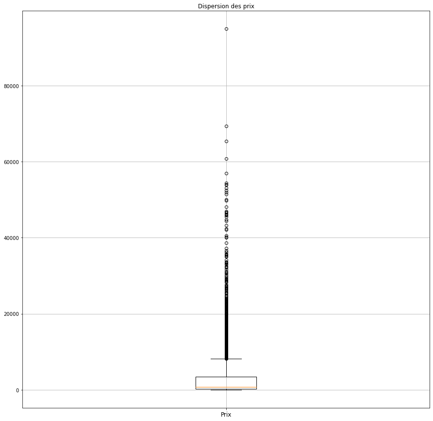

```python
fig = plt.figure(figsize=(15, 15))
ax = fig.add_subplot()
ax.boxplot(VenteCA["Chiffres d'Affaires"].values)
ax.set_title("Dispersion des prix")
plt.grid(True)
plt.legend = ["Prix"]
ax.set_xticklabels(plt.legend, fontsize=12)
plt.show()
```

## Analyse Critere: "Catégorie"

```python
profilCat0= vente[vente['categ'] == 0].groupby(['client_id', 'sex', 'age']).sum().reset_index()
profilCat1= vente[vente['categ'] == 1].groupby(['client_id', 'sex', 'age']).sum().reset_index()
profilCat2 =vente[vente['categ'] == 2].groupby(['client_id', 'sex', 'age']).sum().reset_index()
```

```python
Cat0 = vente[vente['categ']==0]
Cat1 = vente[vente['categ']==1]
Cat2 = vente[vente['categ']==2]
```

```python
Cat0
```

|  | id_prod | date | session_id | client_id | price | categ | sex | age |
| --- | --- | --- | --- | --- | --- | --- | --- | --- |
| 0 | 0_1518 | 2022-05-20 13:21:29.043970 | s_211425 | c_103 | 4.18 | 0 | f | 36 |
| 1 | 0_1518 | 2021-09-26 12:37:29.780414 | s_95811 | c_6197 | 4.18 | 0 | m | 37 |
| 2 | 0_1518 | 2021-05-06 17:14:43.117440 | s_30782 | c_682 | 4.18 | 0 | f | 48 |
| 3 | 0_1518 | 2022-03-16 18:57:10.420103 | s_180057 | c_5932 | 4.18 | 0 | f | 60 |
| 4 | 0_1518 | 2022-11-12 18:58:10.574853 | s_296584 | c_7217 | 4.18 | 0 | f | 46 |
| ... | ... | ... | ... | ... | ... | ... | ... | ... |
| 679527 | 0_1279 | 2021-06-23 06:50:48.888907 | s_52563 | c_1025 | 20.99 | 0 | m | 38 |
| 679528 | 0_1683 | 2021-12-24 04:37:46.407713 | s_139091 | c_5508 | 2.99 | 0 | f | 48 |
| 679529 | 0_1379 | 2021-10-16 09:19:09.546713 | s_105547 | c_5425 | 2.99 | 0 | f | 41 |
| 679530 | 0_886 | 2021-03-17 03:34:14.461358 | s_7410 | c_7219 | 21.82 | 0 | f | 56 |
| 679531 | 0_833 | 2021-09-27 23:22:40.394509 | s_96558 | c_8260 | 2.99 | 0 | m | 31 |

415459 rows × 8 columns

```python
venteCat0 = round(Cat0['price'].sum())
venteCat1 = round(Cat1['price'].sum())
venteCat2 = round(Cat2['price'].sum())
```

```python
print(venteCat0, venteCat1, venteCat2 )
```

```
4419731 4653723 2780275
```

```python
Cat0['price'].count()
Cat1['price'].count()
Cat2['price'].count()
```

```
36483
```

```python
CA_Categ = venteCat0,venteCat1, venteCat2
CA_CategVente = Cat0['price'].count(), Cat1['price'].count(), Cat2['price'].count()
```

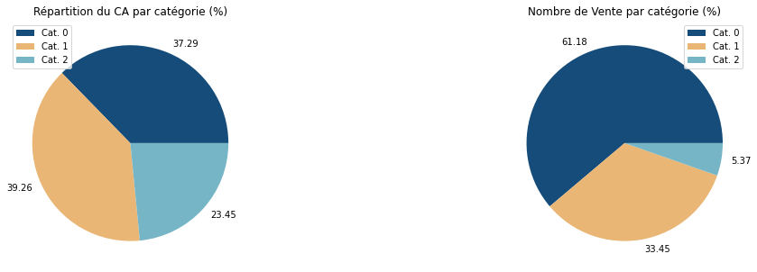

```python
fig = plt.figure(figsize= (18,5))
#CA x Categ
ax = fig.add_subplot(1,2,1)
ax.pie(CA_Categ,
        labels = np.round((CA_Categ/vente['price'].sum()*100),2),
        colors = ['#154c79','#eab676','#76b5c5'])
ax.legend(['Cat. 0', 'Cat. 1','Cat. 2'], loc = "upper left")
ax.set_title("Répartition du CA par catégorie (%)")
#Nb de Vente x Categ
ax2 = fig.add_subplot(1,2,2)
ax2.pie(CA_CategVente,
        labels = np.round((CA_CategVente/vente['price'].count()*100),2),
        colors = ['#154c79','#eab676','#76b5c5'])
ax2.legend(['Cat. 0', 'Cat. 1','Cat. 2'], loc = "upper right")
ax2.set_title("Nombre de Vente par catégorie (%)")
plt.show()
```

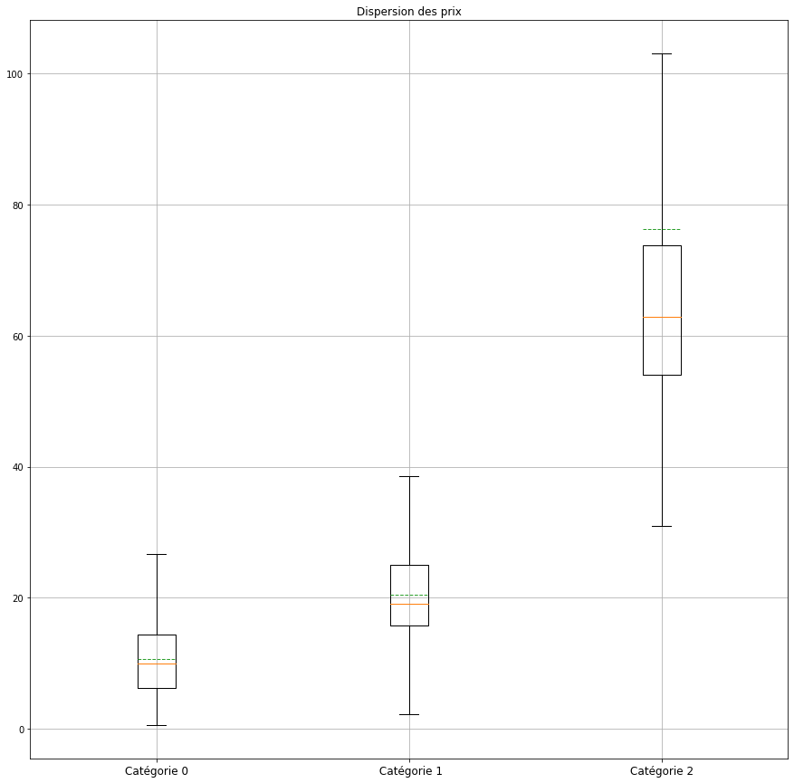

```python
fig = plt.figure(figsize=(15, 15))
ax = fig.add_subplot()
ax.boxplot(Cat0["price"], positions=[1],showfliers=False,meanline=True,
    showmeans=True)
ax.boxplot(Cat1["price"], positions=[2],showfliers=False,meanline=True,
    showmeans=True)
ax.boxplot(Cat2["price"], positions=[3],showfliers=False,meanline=True,
    showmeans=True)
ax.set_title("Dispersion des prix")
plt.grid(True)
plt.legend = ['Catégorie 0', ' Catégorie 1', 'Catégorie 2']
ax.set_xticklabels(plt.legend, fontsize=12)
plt.show()
```

## Analyse Critère: "Temporelle"

### Ventes par mois

#### En Termes de Chiffres d'Affaires

```python
venteTemps = vente.set_index('date')
venteCA_J = venteTemps[['price']].groupby(pd.Grouper(freq='D')).sum()
```

```python
venteCA_J.head()
```

| date | price |
| --- | --- |
| 2021-03-01 | 16565.22 |
| 2021-03-02 | 15486.45 |
| 2021-03-03 | 15198.69 |
| 2021-03-04 | 15196.07 |
| 2021-03-05 | 17471.37 |

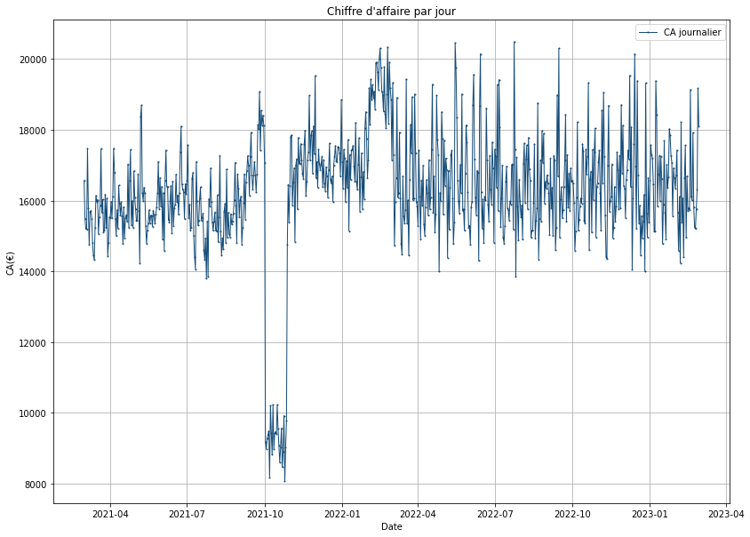

```python
fig = plt.figure(figsize=(30, 10))
ax1 = fig.add_subplot(1, 2, 1)
y = venteCA_J
ax1.plot(venteCA_J.index,
         y.price,
         "o-",
         color='#154c79',
         linewidth=1,
         markersize=1,
         label="CA journalier")
ax1.set_title("Chiffre d'affaire par jour")
#ax1.set_xlabel("Mois")
ax1.legend()
ax1.set_ylabel("CA(€)")
ax1.set_xlabel("Date")
ax1.grid(True)
plt.show()
```

##### Decomposition Chiffres D'Affaires:

```python
from statsmodels.tsa.seasonal import seasonal_decompose
```

```python
#venteCA_Seasonal=seasonal_decompose(venteCA_J, model='multiplicative', period=24)
```

```python
venteCA_Decompose =seasonal_decompose(venteCA_J.price, period=7)
```

```python
venteCA_Seasonal= venteCA_Decompose.seasonal
venteCA_Trend=venteCA_Decompose.trend
venteCA_Resid=venteCA_Decompose.resid
```

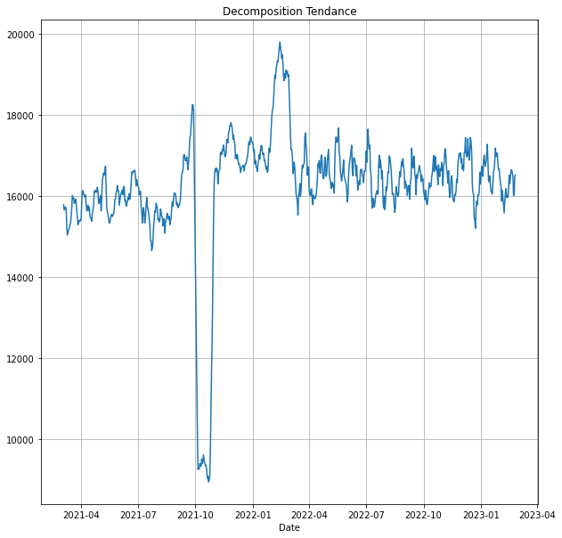

```python
fig,ax = plt.subplots(figsize =(10,10))
ax.plot(venteCA_Trend.index,venteCA_Trend)
ax.set_title("Decomposition Tendance")
ax.set_xlabel("Date")
ax.grid(True);
```

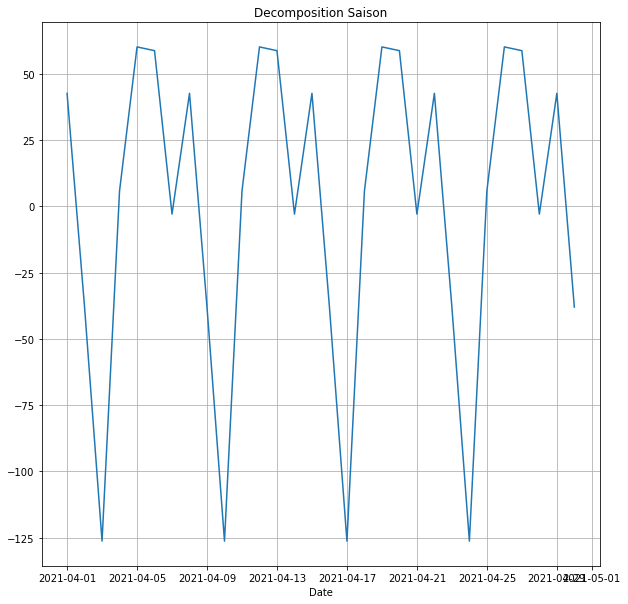

```python
fig,ax = plt.subplots(figsize =(10,10))
ax.plot(venteCA_Seasonal['2021-04'].index,venteCA_Seasonal['2021-04'])
ax.set_title("Decomposition Saison")
ax.set_xlabel("Date")
ax.grid(True);
```

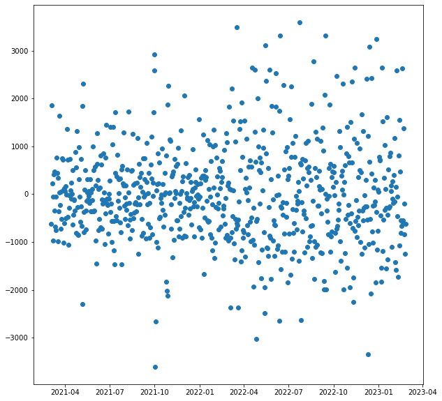

```python
fig,ax = plt.subplots(figsize =(10,10))
ax.scatter(venteCA_Resid.index,venteCA_Resid);
```

##### Moyenne Mobile CA

```python
venteMois_SMA = venteCA_J.rolling(window=7, min_periods=1).mean()
venteMois_SMA
```

| date | price |
| --- | --- |
| 2021-03-01 | 16565.220000 |
| 2021-03-02 | 16025.835000 |
| 2021-03-03 | 15750.120000 |
| 2021-03-04 | 15611.607500 |
| 2021-03-05 | 15983.560000 |
| ... | ... |
| 2023-02-24 | 16488.778571 |
| 2023-02-25 | 16006.747143 |
| 2023-02-26 | 16035.021429 |
| 2023-02-27 | 16487.570000 |
| 2023-02-28 | 16513.984286 |

730 rows × 1 columns

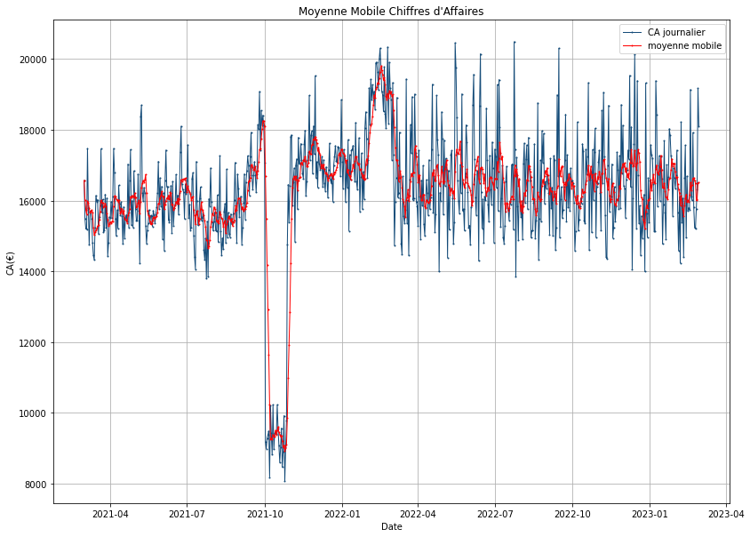

```python
fig = plt.figure(figsize = (30,10))
ax1 = fig.add_subplot(1,2,1)
y = venteCA_J.price
y2 = venteMois_SMA.price
ax1.plot(venteCA_J.index,y, "o-", color='#154c79',  linewidth = 1, markersize=1, label="CA journalier")
ax1.plot(venteMois_SMA.index,y2, "o-", color='red',  linewidth = 1, markersize=1, label="moyenne mobile")

ax1.set_title("Moyenne Mobile Chiffres d'Affaires")
ax1.legend()
ax1.set_ylabel("CA(€)")
ax1.set_xlabel("Date")
ax1.grid(True)
plt.show()
```

```python
venteTemps['2021-10'][venteTemps['categ']==0]
```

| date | id_prod | session_id | client_id | price | categ | sex | age |
| --- | --- | --- | --- | --- | --- | --- | --- |
| 2021-10-11 12:19:17.206620 | 0_1518 | s_103224 | c_5312 | 4.18 | 0 | m | 45 |
| 2021-10-26 11:34:46.658546 | 0_1518 | s_110388 | c_7048 | 4.18 | 0 | m | 41 |
| 2021-10-11 04:07:59.133009 | 0_1518 | s_103072 | c_2455 | 4.18 | 0 | f | 70 |
| 2021-10-15 21:11:33.856657 | 0_1518 | s_105315 | c_5697 | 4.18 | 0 | m | 34 |
| 2021-10-12 07:31:49.081831 | 0_1518 | s_103594 | c_846 | 4.18 | 0 | f | 41 |
| ... | ... | ... | ... | ... | ... | ... | ... |
| 2021-10-16 01:07:24.949008 | 0_898 | s_105378 | c_4805 | 1.27 | 0 | f | 47 |
| 2021-10-31 20:14:20.100190 | 0_1806 | s_112884 | c_229 | 1.61 | 0 | f | 35 |
| 2021-10-03 18:06:24.864280 | 0_1595 | s_99495 | c_4394 | 2.99 | 0 | f | 44 |
| 2021-10-14 01:49:49.367925 | 0_698 | s_104438 | c_5429 | 1.44 | 0 | f | 54 |
| 2021-10-16 09:19:09.546713 | 0_1379 | s_105547 | c_5425 | 2.99 | 0 | f | 41 |

18762 rows × 7 columns

#### En Nombre de Vente

```python
venteNbMois = venteTemps[['id_prod']].groupby(pd.Grouper(freq='D')).count()
venteNbMois.head()
```

| date | id_prod |
| --- | --- |
| 2021-03-01 | 962 |
| 2021-03-02 | 939 |
| 2021-03-03 | 911 |
| 2021-03-04 | 903 |
| 2021-03-05 | 943 |

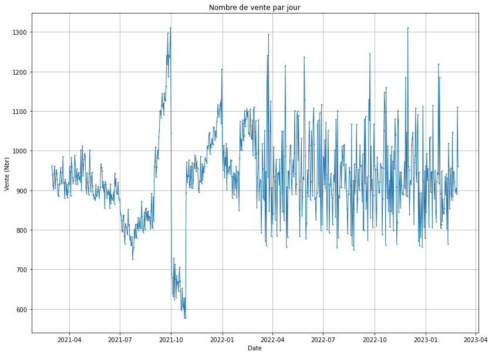

```python
fig = plt.figure(figsize = (30,10))
ax1 = fig.add_subplot(1,2,1)
y = venteNbMois.id_prod
ax1.plot(venteNbMois.index,y, "o-",  linewidth = 1, markersize=1)
ax1.set_title("Nombre de vente par jour")
#ax1.set_xlabel("Mois")
ax1.set_ylabel("Vente (Nbr)")
ax1.set_xlabel("Date")
ax1.grid(True)
plt.show()
```

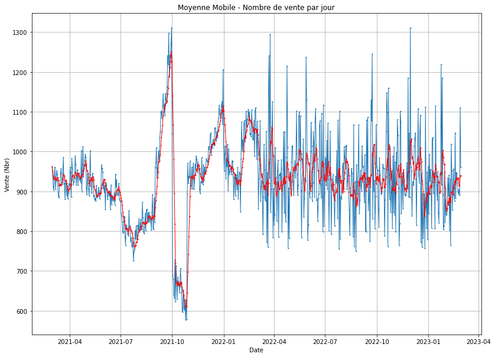

```python
venteMois_SMANb = venteNbMois.rolling(window=7, min_periods=1).mean()
fig = plt.figure(figsize = (30,10))
ax1 = fig.add_subplot(1,2,1)
y = venteNbMois.id_prod
y2 = venteMois_SMANb.id_prod
ax1.plot(venteNbMois.index,y, "o-",  linewidth = 1, markersize=1)
ax1.plot(venteMois_SMANb.index,y2, "o-", color='red',  linewidth = 1, markersize=1, label="moyenne mobile")
ax1.set_title("Moyenne Mobile - Nombre de vente par jour")
#ax1.set_xlabel("Mois")
ax1.set_ylabel("Vente (Nbr)")
ax1.set_xlabel("Date")
ax1.grid(True)
plt.show()
```

### Anomalie Octobre:

```python
categ0Temp= venteTemps[venteTemps['categ']==0]
categ1Temp=venteTemps[venteTemps['categ']==1]
categ2Temp= venteTemps[venteTemps['categ']==2]
```

```python
categ0Temp_J = categ0Temp[['price']].groupby(pd.Grouper(freq='D')).sum()
categ1Temp_J = categ1Temp[['price']].groupby(pd.Grouper(freq='D')).sum()
categ2Temp_J = categ2Temp[['price']].groupby(pd.Grouper(freq='D')).sum()
categ0Temp_Decompose =seasonal_decompose(categ0Temp_J.price, period=7)
categ1Temp_Decompose =seasonal_decompose(categ1Temp_J.price, period=7)
categ2Temp_Decompose =seasonal_decompose(categ2Temp_J.price, period=7)
```

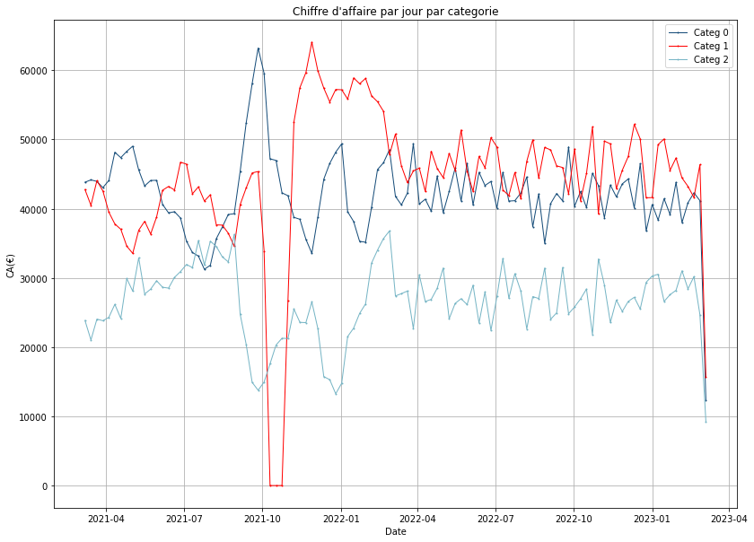

```python
fig = plt.figure(figsize = (30,10))
ax1 = fig.add_subplot(1,2,1)
y = categ0Temp_J[['price']].groupby(pd.Grouper(freq='W')).sum()
ya = categ1Temp_J[['price']].groupby(pd.Grouper(freq='W')).sum()
yb= categ2Temp_J[['price']].groupby(pd.Grouper(freq='W')).sum()
ax1.plot(categ0Temp_J[['price']].groupby(pd.Grouper(freq='W')).sum().index,y.price, "o-", color='#154c79',  linewidth = 1, markersize=1, label="Categ 0")
ax1.plot(categ1Temp_J[['price']].groupby(pd.Grouper(freq='W')).sum().index,ya.price, "o-", color='red',  linewidth = 1, markersize=1, label="Categ 1")
ax1.plot(categ2Temp_J[['price']].groupby(pd.Grouper(freq='W')).sum().index,yb.price, "o-", color='#76b5c5',  linewidth = 1, markersize=1, label="Categ 2")
ax1.set_title("Chiffre d'affaire par jour par categorie")
#ax1.set_xlabel("Mois")
ax1.legend()
ax1.set_ylabel("CA(€)")
ax1.set_xlabel("Date")
ax1.grid(True)
plt.show()
```

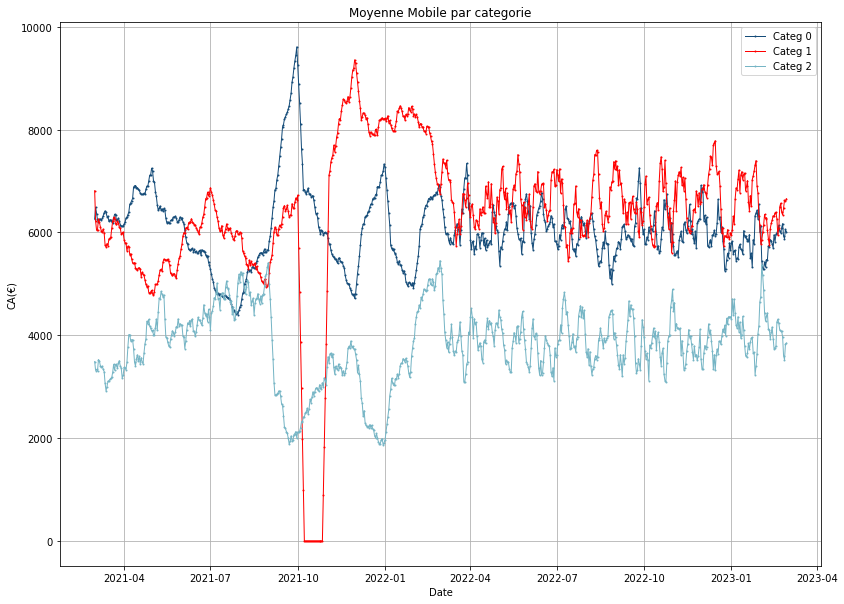

```python
categ0_SMA = categ0Temp_J.rolling(window=7, min_periods=1).mean()
categ1_SMA = categ1Temp_J.rolling(window=7, min_periods=1).mean()
categ2_SMA = categ2Temp_J.rolling(window=7, min_periods=1).mean()
fig = plt.figure(figsize = (30,10))
ax1 = fig.add_subplot(1,2,1)
y = categ0_SMA.price
ya = categ1_SMA.price
yb= categ2_SMA.price
ax1.plot(categ0_SMA.index,y, "o-", color='#154c79',  linewidth = 1, markersize=1, label="Categ 0")
ax1.plot(categ1_SMA.index,ya, "o-", color='red',  linewidth = 1, markersize=1, label="Categ 1")
ax1.plot(categ2_SMA.index,yb, "o-", color='#76b5c5',  linewidth = 1, markersize=1, label="Categ 2")
ax1.set_title("Moyenne Mobile par categorie")
#ax1.set_xlabel("Mois")
ax1.legend()
ax1.set_ylabel("CA(€)")
ax1.set_xlabel("Date")
ax1.grid(True)
plt.show()
```

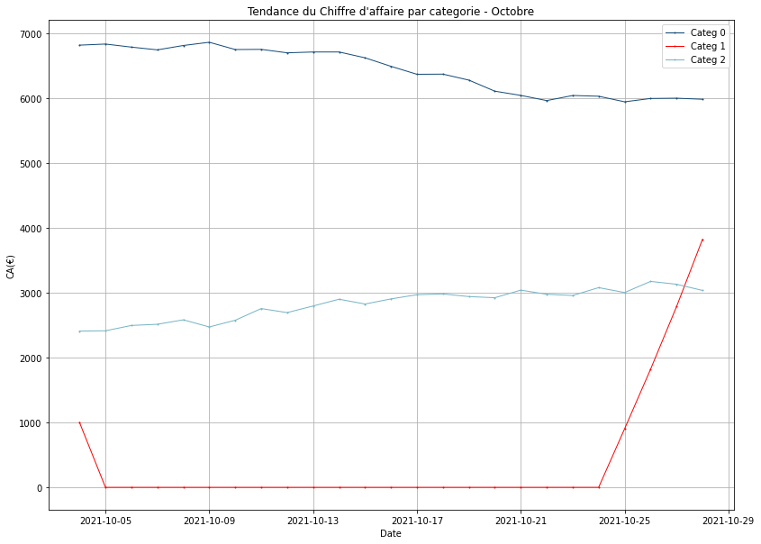

```python
categ0Temp_Decompose2 =seasonal_decompose(categ0Temp_J['2021-10'].price, period=7)
categ1Temp_Decompose2 =seasonal_decompose(categ1Temp_J['2021-10'].price, period=7)
categ2Temp_Decompose2 =seasonal_decompose(categ2Temp_J['2021-10'].price, period=7)
fig = plt.figure(figsize = (30,10))
ax1 = fig.add_subplot(1,2,1)
y = categ0Temp_Decompose2.trend
ya = categ1Temp_Decompose2.trend
yb= categ2Temp_Decompose2.trend
ax1.plot(categ0Temp_Decompose2.trend.index,y, "o-", color='#154c79',  linewidth = 1, markersize=1, label="Categ 0")
ax1.plot(categ1Temp_Decompose2.trend.index,ya, "o-", color='red',  linewidth = 1, markersize=1, label="Categ 1")
ax1.plot(categ2Temp_Decompose2.trend.index,yb, "o-", color='#76b5c5',  linewidth = 1, markersize=1, label="Categ 2")
ax1.set_title("Tendance du Chiffre d'affaire par categorie - Octobre")
#ax1.set_xlabel("Mois")
ax1.legend()
ax1.set_ylabel("CA(€)")
ax1.set_xlabel("Date")
ax1.grid(True)
plt.show()
```

Pour la suite de l'étude, on va exclure les ventes du mois de octobre 2021 de chaque catégorie de notre table de données vente.

```python
vente =  vente[(vente.date <= '2021-09-30') | (vente.date >= '2021-11-01')]
```

### Répartitions CA

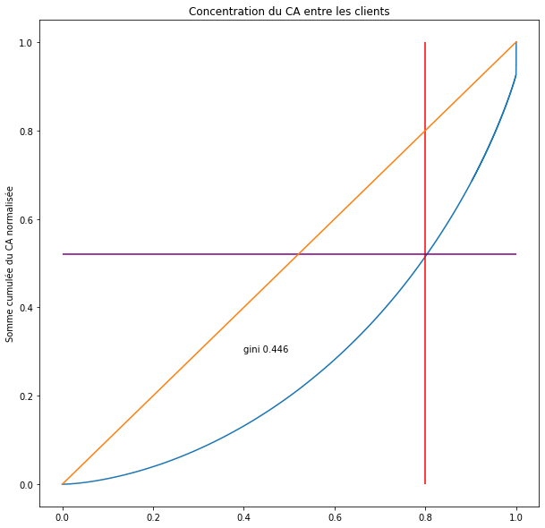

```python
dep = pd.DataFrame(vente.groupby('client_id')['price'].sum()).reset_index().sort_values('price', ascending=False)
dep = dep['price']
n = len(dep)
lorenz = np.cumsum(np.sort(dep)) / dep.sum()
lorenz = np.append([0],lorenz) # La courbe de Lorenz commence à 0


fig,ax = plt.subplots(figsize =(10,10))
xaxis = np.linspace(0-1/n,1+1/n,len(lorenz))
plt.plot(xaxis,lorenz,drawstyle='steps-post', label = "Lorenz")
ax.vlines(x=0.8, ymin=0, ymax=1,colors='red')
ax.hlines(y=0.52, xmin=0, xmax=1,colors='purple')
ax.axes.text(x=0.4, y=0.3, s='gini 0.446')
ax.set_title("Concentration du CA entre les clients")
ax.set_ylabel("Somme cumulée du CA normalisée")
plt.plot([0,1], [0,1], label = "1ère bissectrice") #tracer la bisséctrice
plt.show()
```

```python
AUC = (lorenz.sum() -lorenz[-1]/2 -lorenz[0]/2)/n # Surface sous la courbe de Lorenz. Le premier segment (lorenz[0]) est à moitié en dessous de 0, on le coupe donc en 2, on fait de même pour le dernier segment lorenz[-1] qui est à moitié au dessus de 1.
S = 0.5 - AUC # surface entre la première bissectrice et le courbe de Lorenz
gini = 2*S
print("Indice de gini: {}".format(round(gini,3)))
```

```
Indice de gini: 0.447
```

## Les Tops et Flops

### Produits Tops

##### Top 10 Produits les plus vendus:

```python
topProduit = pd.DataFrame(vente.groupby('id_prod')['session_id'].count()).reset_index().sort_values('session_id', ascending=False)
topProduit = topProduit.rename(columns={"session_id":"Nb Vente"})
topProduit.head(10)
```

|  | id_prod | Nb Vente |
| --- | --- | --- |
| 2589 | 1_369 | 2234 |
| 2642 | 1_417 | 2169 |
| 2639 | 1_414 | 2161 |
| 2731 | 1_498 | 2117 |
| 2651 | 1_425 | 2079 |
| 2627 | 1_403 | 1948 |
| 2637 | 1_412 | 1936 |
| 2638 | 1_413 | 1929 |
| 2630 | 1_406 | 1927 |
| 2631 | 1_407 | 1920 |

```python
topProduit.describe()
```

|  | Nb Vente |
| --- | --- |
| count | 3263.000000 |
| mean | 201.103586 |
| std | 322.583191 |
| min | 1.000000 |
| 25% | 16.000000 |
| 50% | 55.000000 |
| 75% | 232.000000 |
| max | 2234.000000 |

```python
print("Le top 10 des produits vendus répresente {}% du chiffres d'affaires".format(round((VenteCA.sort_values("Chiffres d'Affaires", ascending=False).iloc[:10,1].sum())/VenteCA["Chiffres d'Affaires"].sum()*100,3)))
```

```
Le top 10 des produits vendus répresente 5.189% du chiffres d'affaires
```

```python
print("Le top 10 des produits vendus répresente {}% du nombres de ventes d'articles".format(round((VenteCA.sort_values("Ventes Total", ascending=False).iloc[:10,2].sum())/VenteCA["Ventes Total"].sum()*100,3)))
```

```
Le top 10 des produits vendus répresente 3.03% du nombres de ventes d'articles
```

```python
VenteCA.sort_values("Ventes Total", ascending=False).iloc[:10,2].sum()
```

```
20575
```

### Produit Flops

```python
flop1 = topProduit[topProduit['Nb Vente'] <=1]
flop1
```

|  | id_prod | Nb Vente |
| --- | --- | --- |
| 751 | 0_1683 | 1 |
| 2077 | 0_807 | 1 |
| 664 | 0_1601 | 1 |
| 548 | 0_1498 | 1 |
| 1790 | 0_549 | 1 |
| 2164 | 0_886 | 1 |
| 801 | 0_1728 | 1 |
| 3261 | 2_98 | 1 |
| 1782 | 0_541 | 1 |
| 594 | 0_1539 | 1 |
| 588 | 0_1533 | 1 |
| 313 | 0_1284 | 1 |
| 2269 | 0_980 | 1 |
| 2177 | 0_898 | 1 |
| 3245 | 2_81 | 1 |
| 3173 | 2_23 | 1 |
| 2106 | 0_833 | 1 |
| 166 | 0_1151 | 1 |
| 697 | 0_1633 | 1 |
| 656 | 0_1595 | 1 |
| 257 | 0_1233 | 1 |

```python
flopNonVente = rappCA[rappCA["transaction_product"]=="right_only"].count()
flopNonVente["id_prod"]
```

```
21
```

```python
print("On retrouve {} article non vendus et {} articles qui ont vendus une copie".format(flopNonVente["id_prod"],flop1["id_prod"].count()))
```

```
On retrouve 21 article non vendus et 21 articles qui ont vendus une copie
```

##### Client qui achete le plus:

```python
topClientCA = pd.DataFrame(vente.groupby('client_id')['price'].sum()).reset_index().sort_values('price', ascending=False)
topClientCA = topClientCA.rename(columns={"price":"Chiffre Affaire"})
topClientCA.head(10)
```

|  | client_id | Chiffre Affaire |
| --- | --- | --- |
| 677 | c_1609 | 312247.61 |
| 4387 | c_4958 | 282289.70 |
| 6336 | c_6714 | 149484.49 |
| 2723 | c_3454 | 111638.84 |
| 2108 | c_2899 | 5214.05 |
| 634 | c_1570 | 5136.14 |
| 2513 | c_3263 | 5129.89 |
| 7005 | c_7319 | 5078.48 |
| 7790 | c_8026 | 4969.41 |
| 4725 | c_5263 | 4964.87 |

```python
topClientCA["Chiffre Affaire"].sum()
```

```
11514801.929999998
```

```python
print("Les top 4 clients genere {}% du chiffres d'affaires".format(round((sum(topClientCA.iloc[3:,1])/sum(vente['price'])*100),2)))
```

[output not shown]

```python
topClientNbVente = pd.DataFrame(vente.groupby('client_id')['session_id'].count()).reset_index().sort_values('session_id', ascending=False)
topClientNbVente = topClientNbVente.rename(columns={"session_id":"Nb Vente"})
topClientNbVente.head(10)
```

|  | client_id | Nb Vente |
| --- | --- | --- |
| 677 | c_1609 | 24427 |
| 6336 | c_6714 | 8875 |
| 2723 | c_3454 | 6623 |
| 4387 | c_4958 | 5085 |
| 2513 | c_3263 | 392 |
| 1772 | c_2595 | 384 |
| 1268 | c_2140 | 378 |
| 1197 | c_2077 | 370 |
| 7316 | c_760 | 368 |
| 7119 | c_7421 | 368 |

```python
print("Les top 4 clients genere {}% du nombre de livres vendu".format(round((sum(topClientNbVente.iloc[0:3,1])/(vente['session_id'].count())*100),2)))
```

[output not shown]

```python
topClientNbVente[topClientNbVente['Nb Vente'] <=1]
```

|  | client_id | Nb Vente |
| --- | --- | --- |
| 694 | c_1624 | 1 |
| 3246 | c_3927 | 1 |
| 920 | c_1828 | 1 |
| 6516 | c_6879 | 1 |
| 5867 | c_6292 | 1 |
| 3809 | c_4436 | 1 |
| 1991 | c_2793 | 1 |
| 3854 | c_4478 | 1 |
| 5500 | c_5962 | 1 |
| 3575 | c_4223 | 1 |
| 4043 | c_4648 | 1 |
| 1556 | c_240 | 1 |

## Analyse Critere: "Age"

```python
profil = pd.merge(topClientCA,customers,how="left",on="client_id")
profil = pd.merge(topClientNbVente,profil,how="left",on="client_id")
profil.drop(columns=['birth'], inplace=True)
profil.age.describe()
```

```
count    8598.000000
mean       43.739591
std        16.909801
min        18.000000
25%        30.000000
50%        43.000000
75%        56.000000
max        93.000000
Name: age, dtype: float64
```

```python
profil.sort_values("Chiffre Affaire", ascending=False).head(20)
```

|  | client_id | Nb Vente | Chiffre Affaire | sex | age |
| --- | --- | --- | --- | --- | --- |
| 0 | c_1609 | 24427 | 312247.61 | m | 42 |
| 3 | c_4958 | 5085 | 282289.70 | m | 23 |
| 1 | c_6714 | 8875 | 149484.49 | f | 54 |
| 2 | c_3454 | 6623 | 111638.84 | m | 53 |
| 1803 | c_2899 | 105 | 5214.05 | f | 28 |
| 15 | c_1570 | 356 | 5136.14 | f | 43 |
| 4 | c_3263 | 392 | 5129.89 | f | 37 |
| 11 | c_7319 | 365 | 5078.48 | f | 48 |
| 10 | c_8026 | 367 | 4969.41 | m | 44 |
| 2051 | c_5263 | 96 | 4964.87 | m | 24 |
| 9 | c_7421 | 368 | 4944.39 | m | 44 |
| 6 | c_2140 | 378 | 4937.70 | f | 45 |
| 12 | c_1422 | 362 | 4878.25 | f | 42 |
| 31 | c_1876 | 341 | 4780.08 | m | 39 |
| 5 | c_2595 | 384 | 4778.69 | m | 48 |
| 54 | c_4840 | 320 | 4769.15 | m | 50 |
| 28 | c_2505 | 346 | 4762.26 | f | 40 |
| 25 | c_794 | 348 | 4751.18 | f | 48 |
| 23 | c_8392 | 349 | 4730.95 | f | 44 |
| 20 | c_880 | 350 | 4728.82 | m | 31 |

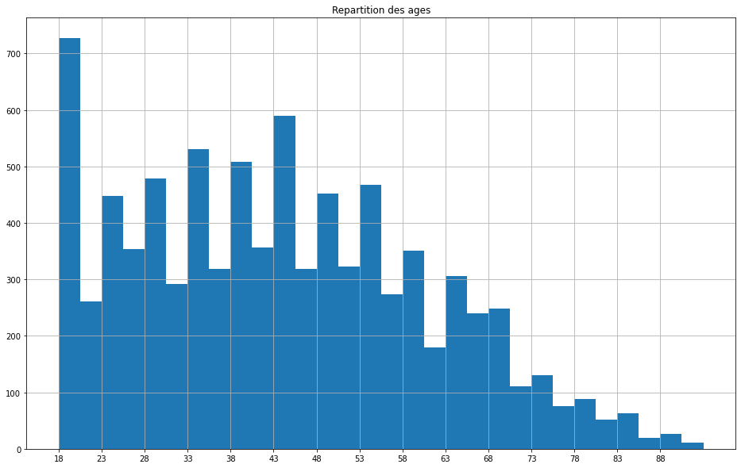

```python
fig, ax = plt.subplots(figsize =(16,10))
plt.hist(profil['age'], bins= 'auto', stacked=True)
ax.set_title('Repartition des ages')
ticks_positions = np.arange(profil.age.min(), profil.age.max(), 5)
ax.set_xticks(ticks_positions)
ax.grid(True)
plt.show()
```

```python
profil[profil['age'] == 18].head()
```

[output not shown]

[output cut: 407 more lines]

```python
print("La classe de 18ans represente {}% du chiffre d'affaires soit {}€".format(round((profil[profil['age'] == 18]['Chiffre Affaire'].sum()/profil['Chiffre Affaire'].sum())*100,2), round(profil[profil['age'] == 18]['Chiffre Affaire'].sum())))
```

```
La classe de 18ans represente 5.13% du chiffre d'affaires soit 591017€
```

### Analyse par Tranche D'age:

```python
pd.qcut(profil['age'], 8)
```

```
0         (36.0, 43.0]
1         (49.0, 56.0]
2         (49.0, 56.0]
3       (17.999, 23.0]
4         (36.0, 43.0]
             ...
8593      (49.0, 56.0]
8594      (23.0, 30.0]
8595      (65.0, 93.0]
8596    (17.999, 23.0]
8597      (23.0, 30.0]
Name: age, Length: 8598, dtype: category
Categories (8, interval[float64, right]): [(17.999, 23.0] < (23.0, 30.0] < (30.0, 36.0] < (36.0, 43.0] < (43.0, 49.0] < (49.0, 56.0] < (56.0, 65.0] < (65.0, 93.0]]
```

```python
profil['Age_qcut'] = pd.qcut(profil['age'], 8, labels=['18-23ans', '24-30ans',
                                  '31-36ans', '37-43ans',
                                  '44-49ans', '50-56ans',
                                  '57-65ans', '66ans et plus'] )
etude_Age = profil[['Age_qcut', 'Chiffre Affaire']]
etude_Age = pd.DataFrame(etude_Age.groupby('Age_qcut')['Chiffre Affaire'].sum())
etude_Age['effectifs'] = pd.DataFrame(profil.groupby('Age_qcut')['Chiffre Affaire'].count())
etude_Age=etude_Age.reset_index()
etude_Age
```

|  | Age_qcut | Chiffre Affaire | effectifs |
| --- | --- | --- | --- |
| 0 | 18-23ans | 1753091.08 | 1147 |
| 1 | 24-30ans | 1447625.47 | 1120 |
| 2 | 31-36ans | 1523817.61 | 1026 |
| 3 | 37-43ans | 2142881.00 | 1194 |
| 4 | 44-49ans | 1483075.43 | 1004 |
| 5 | 50-56ans | 1301775.73 | 1060 |
| 6 | 57-65ans | 919318.58 | 981 |
| 7 | 66ans et plus | 943217.03 | 1066 |

```python
profil.head()
```

|  | client_id | Nb Vente | Chiffre Affaire | sex | age | Age_qcut |
| --- | --- | --- | --- | --- | --- | --- |
| 0 | c_1609 | 24427 | 312247.61 | m | 42 | 37-43ans |
| 1 | c_6714 | 8875 | 149484.49 | f | 54 | 50-56ans |
| 2 | c_3454 | 6623 | 111638.84 | m | 53 | 50-56ans |
| 3 | c_4958 | 5085 | 282289.70 | m | 23 | 18-23ans |
| 4 | c_3263 | 392 | 5129.89 | f | 37 | 37-43ans |

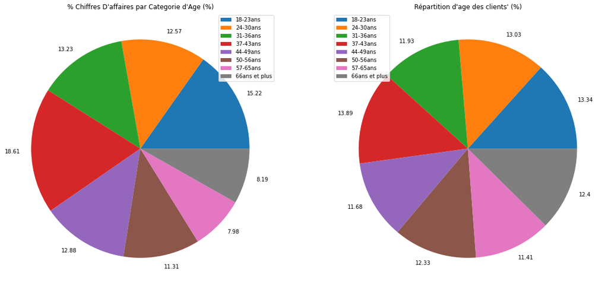

```python
fig = plt.figure(figsize= (20,10))
legends = ['18-23ans', '24-30ans', '31-36ans', '37-43ans',  '44-49ans', '50-56ans', '57-65ans', '66ans et plus']
#CA x AGE
AgeCA = etude_Age['Chiffre Affaire']
ax = fig.add_subplot(1,2,1)
ax.pie(AgeCA,
        labels = np.round((AgeCA/profil['Chiffre Affaire'].sum()*100),2))
ax.legend(legends, loc = "best")
ax.set_title("% Chiffres D'affaires par Categorie d'Age (%)")

#REP x AGE
AgeCount= etude_Age['effectifs']
ax = fig.add_subplot(1,2,2)
ax.pie(AgeCount,
        labels = np.round((AgeCount/profil['age'].count()*100),2))
ax.legend(legends, loc = "upper left")
ax.set_title("Répartition d'age des clients' (%)");
```

```python
print("On retrouve {} clients dans la categorie Jeune, {} age moyen et {} en agee".format(AgeCount[0],AgeCount[1],AgeCount[2]))
```

[output not shown]

```python
print("{}€ generee par la categorie d'age Jeune, {}€ age moyen et {}€ chez Agee".format(round(AgeCA[0]),round(AgeCA[1]),round(AgeCA[2])))
```

[output not shown]

### Répartions Age par Sexe

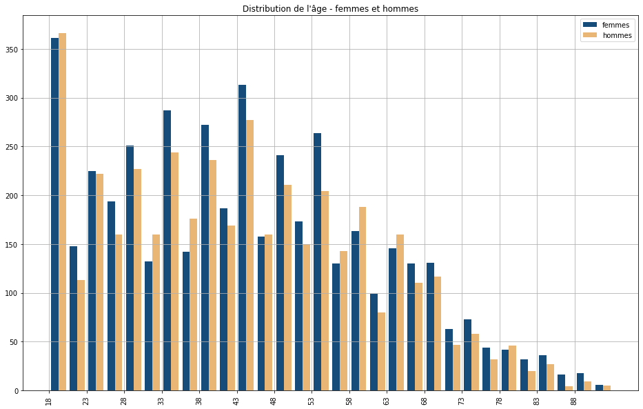

```python
fig, ax = plt.subplots(figsize =(16,10))
ax.hist([profil[profil["sex"]== "f"]["age"],profil[profil["sex"]== "m"]["age"]], bins = 'auto', color = ["#154c79","#eab676"], label = ["femmes","hommes"])

ax.set_xticks(ticks_positions)
ax.set_xticklabels(ticks_positions, rotation = 90)
ax.grid(True)
ax.legend()
ax.set_title("Distribution de l'âge - femmes et hommes");
```

```python
venteNbSexCateg = vente.pivot_table(values = "id_prod", index = "categ", columns = "sex", aggfunc='count', margins=True,margins_name="total")
venteNbSexCateg
```

| sex categ | f | m | total |
| --- | --- | --- | --- |
| 0 | 196531 | 199216 | 395747 |
| 1 | 113927 | 111234 | 225161 |
| 2 | 16712 | 18581 | 35293 |
| total | 327170 | 329031 | 656201 |

```python
femmeTotal = venteNbSexCateg.iloc[3,0]
hommeTotal=venteNbSexCateg.iloc[3,1]
```

```python
print("La difference d'article vendus par rapport aux sexe du client est {} acheter par les femmes et {} par les hommes soit une difference de {} articles".format(femmeTotal,hommeTotal, (hommeTotal-femmeTotal)))
```

```
La difference d'article vendus par rapport aux sexe du client est 327170 acheter par les femmes et 329031 par les hommes soit une difference de 1861 articles
```

# Analyses Corrélationnel

## Lien Entre Genre Client et Catégories de Livre Achetés

```python
#On fait une table a part pour les clients type "business"
venteBusiness = vente[vente["client_id"].isin(["c_1609","c_4958","c_6714","c_3454"])]
vente = vente[~vente["client_id"].isin(["c_1609","c_4958","c_6714","c_3454"])]
```

```python
venteNbSexCateg.transpose()
```

| categ sex | 0 | 1 | 2 | total |
| --- | --- | --- | --- | --- |
| f | 196531 | 113927 | 16712 | 327170 |
| m | 199216 | 111234 | 18581 | 329031 |
| total | 395747 | 225161 | 35293 | 656201 |

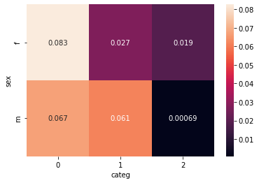

```python
tx = venteNbSexCateg.transpose().loc[:,["total"]]
ty = venteNbSexCateg.transpose().loc[["total"],:]
n = len(vente)
indep = tx.dot(ty) / n

c = venteNbSexCateg.transpose().fillna(0)
measure = (c-indep)**2/indep
xi_n = measure.sum().sum()
table = measure/xi_n
sns.heatmap(table.iloc[:-1,:-1],annot=True)
plt.show()
```

```python
indep.round()
```

| categ sex | 0 | 1 | 2 | total |
| --- | --- | --- | --- | --- |
| f | 211843.0 | 120528.0 | 18892.0 | 351264.0 |
| m | 213048.0 | 121214.0 | 19000.0 | 353262.0 |
| total | 424891.0 | 241743.0 | 37892.0 | 704526.0 |

```python
table
```

| categ sex | 0 | 1 | 2 | total |
| --- | --- | --- | --- | --- |
| f | 0.082637 | 0.026997 | 0.018788 | 0.123396 |
| m | 0.067053 | 0.061353 | 0.000689 | 0.124098 |
| total | 0.149261 | 0.084922 | 0.013311 | 0.247494 |

```python
measure
```

| categ sex | 0 | 1 | 2 | total |
| --- | --- | --- | --- | --- |
| f | 1106.752992 | 361.570837 | 251.623979 | 1652.637722 |
| m | 898.035679 | 821.701702 | 9.230212 | 1662.038214 |
| total | 1999.041540 | 1137.358444 | 178.275952 | 3314.675936 |

```python
c.iloc[:-1,:-1]
```

| categ sex | 0 | 1 | 2 |
| --- | --- | --- | --- |
| f | 196531 | 113927 | 16712 |
| m | 199216 | 111234 | 18581 |

```python
print("H0 = Les variables sex et categorie sont indépendantes \nH1 = Les variables sex et categorie sont liées")
```

```
H0 = Les variables sex et categorie sont indépendantes
H1 = Les variables sex et categorie sont liées
```

```python
from scipy.stats import chi2_contingency

stats_chi2, stats_p, stats_dof, stats_exp = chi2_contingency(venteNbSexCateg.transpose().iloc[:-1,:-1])
print ('Khi2=',round(stats_chi2),'  p_value=',stats_p)

if stats_p<0.05:
    print("on rejette l'hypothèse d'indépendance H0 avec un risque de se tromper à 5%")
else:
    print("on ne rejette pas l'hypothèse d'indépensance H0, au seuil de se tromper à 5%")
```

```
Khi2= 144   p_value= 5.053521532856552e-32
on rejette l'hypothèse d'indépendance H0 avec un risque de se tromper à 5%
```

```python
print("Le sex à une influence sur le type de categorie acheter")
```

```
Le sex à une influence sur le type de categorie acheter
```

## Liens Entre Age et Differents Criteres d'Achats

### âge des clients et le montant total des achats

```python
montant_achat_age = profil[profil["Chiffre Affaire"]<100000]
```

```python
montant_achat_age.rename(columns={'Chiffre Affaire':'price'}, inplace=True)
```

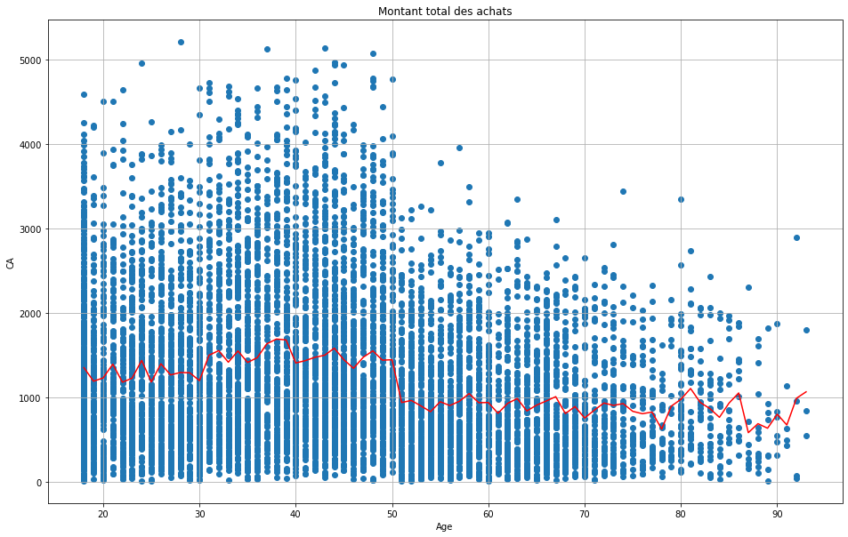

```python
fig, ax = plt.subplots(figsize =(16,10))
ax.scatter(montant_achat_age.age, montant_achat_age.price)
ax.set_title("Montant total des achats")
ax.set_ylabel("CA")
ax.set_xlabel("Age")
plt.grid(True)

plt.plot(montant_achat_age.groupby("age").mean().index, montant_achat_age.groupby("age").mean().price, color='red')
plt.show()
```

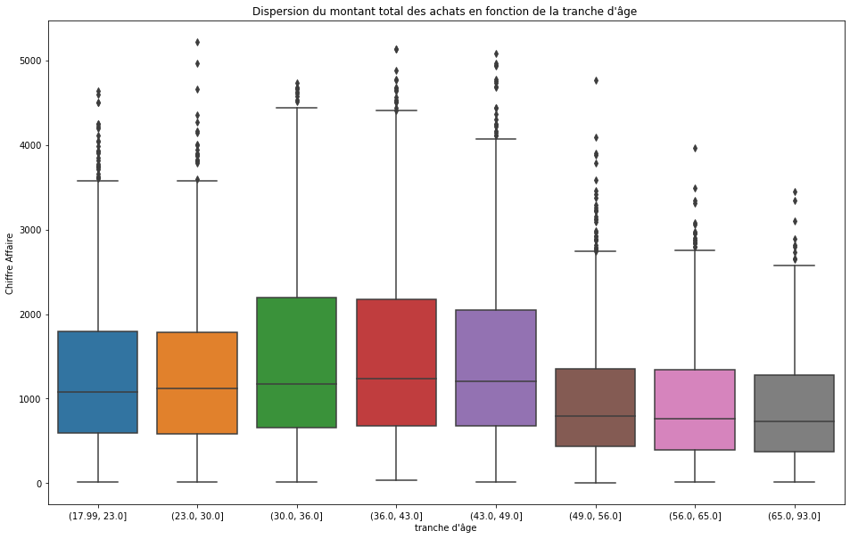

```python
profil["tranche d'âge"] = pd.cut(
    profil[profil["Chiffre Affaire"]<100000].age, bins=[17.99, 23, 30, 36, 43, 49, 56, 65, 93])
fig_CA_age_boxplots = plt.figure(figsize=(16, 10))
sns.boxplot(x="tranche d'âge", y=profil[profil["Chiffre Affaire"]<100000]['Chiffre Affaire'], data=profil[profil["Chiffre Affaire"]<100000])
plt.title(
    "Dispersion du montant total des achats en fonction de la tranche d'âge ")
plt.show()
```

```python
print("H0: On suppose qu'il n'y a pas de liens entre les variables age et montant total des achats, elles sont indépendantes",
     "\nH1:On suppose qu'il y'as bien un lien entre les variables age et montant total des achats, elles ne sont pas indépendantes")
```

```
H0: On suppose qu'il n'y a pas de liens entre les variables age et montant total des achats, elles sont indépendantes
H1:On suppose qu'il y'as bien un lien entre les variables age et montant total des achats, elles ne sont pas indépendantes
```

On calcule si nos données suit une distribution normale:

```python
k2, pval = stats.normaltest(montant_achat_age.age)
seuil = 5e-3
if pval < seuil :
    print("H0 rejeter, la variable age ne suit pas une distribution normal")
else:
    print("H0 ne peut pas etre rejeter, la variable age suit une distribution normal")
```

```
H0 rejeter, la variable age ne suit pas une distribution normal
```

```python
k2, pval = stats.normaltest(montant_achat_age.price)
seuil = 5e-3
if pval < seuil :
    print("H0 rejeter, la variable montant ne suit pas une distribution normal")
else:
    print("H0 ne peut pas etre rejeter, la variable montant suit une distribution normal")
```

```
H0 rejeter, la variable montant ne suit pas une distribution normal
```

```python
print(stats.linregress(montant_achat_age.age, montant_achat_age.price, alternative='two-sided'))
```

```
LinregressResult(slope=-10.114627997285318, intercept=1682.7135290676692, rvalue=-0.18408986737782038, pvalue=2.2099182831556456e-66, stderr=0.582621344724295, intercept_stderr=27.322086532304912)
```

Nos variables ne suivent pas une distribution normale et par intérprétation graphique, on peut observer une distribution non monotone donc le calcul de corrélation de kendall est mieux adapté.

```python
cor, pval = stats.kendalltau(montant_achat_age.age, montant_achat_age.price)
print('kendall correlation coefficient : {} \nPval : {}'.format(round(cor,3), pval))

if pval > 0.05:
    print("H0: On suppose qu'il n'y a pas de liens entre les variables age et montant total des achats, elles sont indépendantes")
else:
    print("H1:On suppose qu'il y'as bien un lien entre les variables age et montant total des achats, elles ne sont pas indépendantes")
```

```
kendall correlation coefficient : -0.12
Pval : 1.0362530887901159e-61
H1:On suppose qu'il y'as bien un lien entre les variables age et montant total des achats, elles ne sont pas indépendantes
```

### âge des clients et la fréquence d’achat

```python
freq_achat_age = vente.loc[:,['client_id','session_id','age']].groupby(['client_id','age']).count().reset_index()
freq_achat_age['f'] = freq_achat_age['session_id'] / sum(freq_achat_age['session_id'])
freq_achat_age
```

|  | client_id | age | session_id | f |
| --- | --- | --- | --- | --- |
| 0 | c_1 | 67 | 38 | 0.000062 |
| 1 | c_10 | 66 | 58 | 0.000095 |
| 2 | c_100 | 30 | 8 | 0.000013 |
| 3 | c_1000 | 56 | 122 | 0.000200 |
| 4 | c_1001 | 40 | 95 | 0.000155 |
| ... | ... | ... | ... | ... |
| 8589 | c_995 | 67 | 14 | 0.000023 |
| 8590 | c_996 | 52 | 94 | 0.000154 |
| 8591 | c_997 | 28 | 58 | 0.000095 |
| 8592 | c_998 | 21 | 53 | 0.000087 |
| 8593 | c_999 | 58 | 44 | 0.000072 |

8594 rows × 4 columns

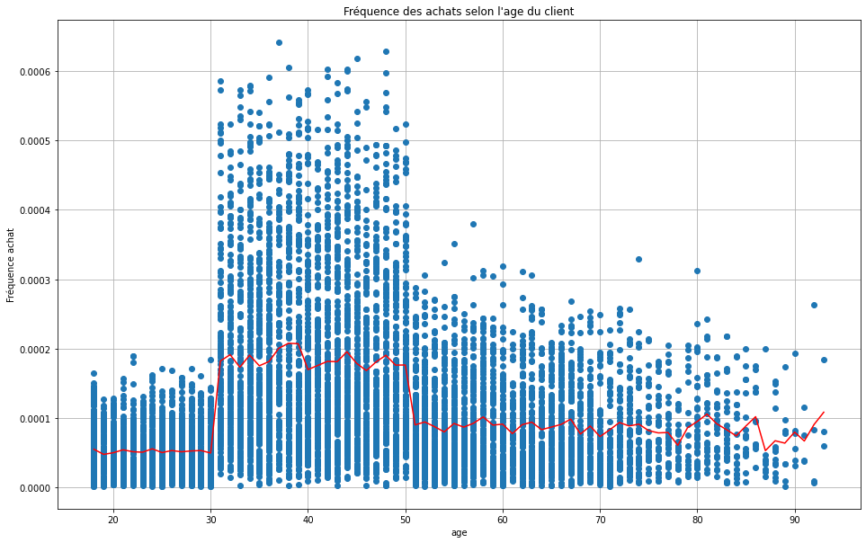

```python
fig, ax = plt.subplots(figsize =(16,10))
plt.plot(freq_achat_age.age, freq_achat_age.f, 'o')

plt.xlabel('age')
plt.ylabel('Fréquence achat')
plt.title('Fréquence des achats selon l\'age du client')
plt.grid('True')
plt.plot(freq_achat_age.groupby("age").mean().index, freq_achat_age.groupby("age").mean().f, color='red')
plt.show()
```

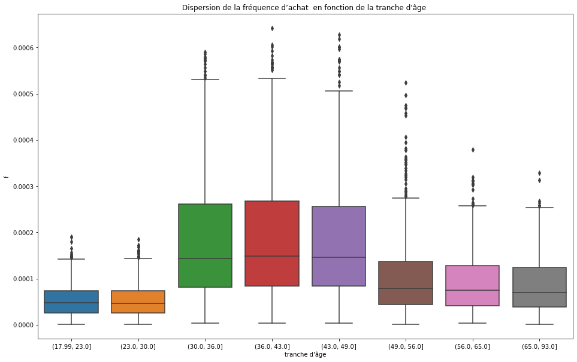

```python
freq_achat_age["tranche d'âge"] = pd.cut(freq_achat_age.age,bins = [17.99,23,30,36,43,49,56,65,93])

plt.figure(figsize =(16,10))
sns.boxplot(x="tranche d'âge",y='f',data=freq_achat_age)
plt.title("Dispersion de la fréquence d’achat  en fonction de la tranche d'âge ")
plt.show()
```

Test de Corrélations: H0: On suppose qu'il n'y a pas de liens entre les variables age et la fréquence d'achat, elles sont indépendantes", H1:On suppose qu'il y'as bien un lien entre les variables age et la fréquence d'achats, elles ne sont pas indépendantes")

```python
k2, pval = stats.normaltest(freq_achat_age.age)
seuil = 5e-3
if pval < seuil :
    print("H0 rejeter, la variable age ne suit pas une distribution normal")
else:
    print("H0 ne peut pas etre rejeter, la variable age suit une distribution normal")
```

```
H0 rejeter, la variable age ne suit pas une distribution normal
```

```python
k2, pval = stats.normaltest(freq_achat_age.f)
seuil = 5e-3
if pval < seuil :
    print("H0 rejeter, la variable montant ne suit pas une distribution normal")
else:
    print("H0 ne peut pas etre rejeter, la variable fréquence suit une distribution normal")
```

```
H0 rejeter, la variable montant ne suit pas une distribution normal
```

```python
print(stats.linregress(freq_achat_age.age, freq_achat_age.f, alternative='two-sided'))
```

```
LinregressResult(slope=2.0813823136142647e-07, intercept=0.00010725629866104356, rvalue=0.03287998950747961, pvalue=0.002300008786253395, stderr=6.82555816474789e-08, intercept_stderr=3.2008523631548586e-06)
```

Nos variables ne suivent pas une distribution normale et par intérprétation graphique, on peut observer une distribution non monotone donc le calcul de corrélation de kendall est mieux adapté.

```python
cor, pval = stats.kendalltau(freq_achat_age.age, freq_achat_age.f)
print('kendall correlation coefficient : {} \nPval : {}'.format(round(cor,3), pval))

if pval > 0.05:
    print("H0: On suppose qu'il n'y a pas de liens entre les variables age et fréquence des achats, elles sont indépendantes")
else:
    print("H1:On suppose qu'il y'as bien un lien entre les variables age et fréquence des achats, elles ne sont pas indépendantes")
```

```
kendall correlation coefficient : 0.08
Pval : 2.4483838893375083e-28
H1:On suppose qu'il y'as bien un lien entre les variables age et fréquence des achats, elles ne sont pas indépendantes
```

### âge des clients et la taille du panier moyen

```python
taille_panier_age = vente.loc[:,['client_id','session_id','age','id_prod']].groupby(['client_id','age','session_id']).count().reset_index()
taille_panier_age = taille_panier_age.groupby(['client_id', 'age']).mean().reset_index()
taille_panier_age.rename(columns={'id_prod':'panier'}, inplace = True)
taille_panier_age
```

|  | client_id | age | panier |
| --- | --- | --- | --- |
| 0 | c_1 | 67 | 1.187500 |
| 1 | c_10 | 66 | 1.705882 |
| 2 | c_100 | 30 | 1.600000 |
| 3 | c_1000 | 56 | 1.340659 |
| 4 | c_1001 | 40 | 2.209302 |
| ... | ... | ... | ... |
| 8589 | c_995 | 67 | 1.555556 |
| 8590 | c_996 | 52 | 1.205128 |
| 8591 | c_997 | 28 | 2.521739 |
| 8592 | c_998 | 21 | 2.304348 |
| 8593 | c_999 | 58 | 1.100000 |

8594 rows × 3 columns

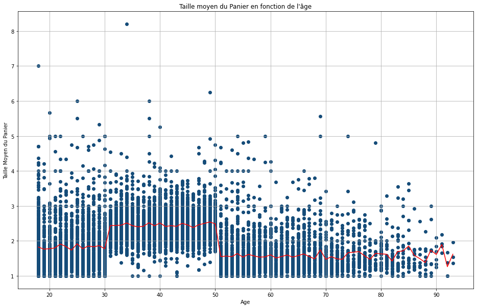

```python
fig, ax = plt.subplots(figsize =(16,10))
ax.scatter(taille_panier_age.age, taille_panier_age.panier, color = '#154c79')
ax.set_title("Taille moyen du Panier en fonction de l'âge")
ax.set_ylabel("Taille Moyen du Panier")
ax.set_xlabel("Age")
plt.plot(taille_panier_age.groupby("age").mean().index, taille_panier_age.groupby("age").mean().panier, color='red')
plt.grid(True)
plt.show()
```

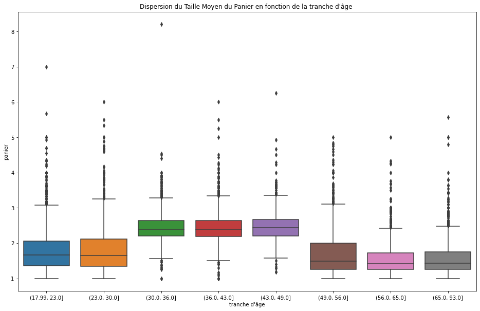

```python
taille_panier_age["tranche d'âge"] = pd.cut(taille_panier_age.age,bins = [17.99,23,30,36,43,49,56,65,93])

plt.figure(figsize =(16,10))
sns.boxplot(x="tranche d'âge",y=taille_panier_age.panier,data=taille_panier_age)
plt.title("Dispersion du Taille Moyen du Panier en fonction de la tranche d'âge ")
plt.show()
```

```python
k2, pval = stats.normaltest(taille_panier_age.age)
seuil = 5e-3
if pval < seuil :
    print("H0 rejeter, la variable age ne suit pas une distribution normal")
else:
    print("H0 ne peut pas etre rejeter, la variable age suit une distribution normal")
```

```
H0 rejeter, la variable age ne suit pas une distribution normal
```

```python
k2, pval = stats.normaltest(taille_panier_age.panier)
seuil = 5e-3
if pval < seuil :
    print("H0 rejeter, la variable montant ne suit pas une distribution normal")
else:
    print("H0 ne peut pas etre rejeter, la variable panier suit une distribution normal")
```

```
H0 rejeter, la variable montant ne suit pas une distribution normal
```

```python
print(stats.linregress(taille_panier_age.age, taille_panier_age.panier, alternative='two-sided'))
```

```
LinregressResult(slope=-0.00830573404046624, intercept=2.349250858567709, rvalue=-0.2073199561447297, pvalue=4.474527667021043e-84, stderr=0.0004228145557942197, intercept_stderr=0.01982793109990571)
```

Nos variables ne suivent pas une distribution normale et par intérprétation graphique, on peut observer une distribution non monotone donc le calcul de corrélation de kendall est mieux adapté.

```python
cor, pval = stats.kendalltau(taille_panier_age.age, taille_panier_age.panier)
print('kendall correlation coefficient : {} \nPval : {}'.format(round(cor,3), pval))

if pval > 0.05:
    print("H0: On suppose qu'il n'y a pas de liens entre les variables age et taille du panier moyen, elles sont indépendantes")
else:
    print("H1:On suppose qu'il y'as bien un lien entre les variables age et taille du panier moyen, elles ne sont pas indépendantes")
```

```
kendall correlation coefficient : -0.13
Pval : 5.670381227167157e-71
H1:On suppose qu'il y'as bien un lien entre les variables age et taille du panier moyen, elles ne sont pas indépendantes
```